# Аналитический отчет для HR-отдела

Перед вами стоит задача – подготовить аналитический отчет для HR-отдела. На основании проведенной аналитики предполагается составить рекомендации для отдела кадров по стратегии набора персонала, а также по взаимодействию с уже имеющимися сотрудниками.  
В базе данных лежит набор таблиц, которые содержат данные о сотрудниках вымышленной компании. Сделайте обзор штата сотрудников компании. Составьте набор предметов исследования, а затем проверьте их на данных. Вся аналитика должна быть выполена с помощью SQL. Впоследствии данные можно визуализировать, однако финальные датафреймы для графиков также должны быть подготовлены с помощью SQL.

Примеры гипотез:

1. Есть зависимость между `perfomance score` и тем, под чьим руководством работает сотрудник.
2. Есть зависимость между продолжительностью работы в компании и семейным положением сотрудника.
3. Есть зависимость между продолжительностью работы в компании и возрастом сотрудника.

Оригинальный датасет на kaggle: [Human Resources Data Set](https://www.kaggle.com/datasets/rhuebner/human-resources-data-set)

### Содержание

1. Подготовка и настройка  
1.1. Импорт библиотек  
1.2. Настройка и проверка соединения с базой данных  
1.3. Запросы и функции  
1.3.1. Описание данных  
1.3.2. Расчет корреляционной матрицы  
1.3.3. Расчет сводной таблицы  
1.3.4. Визуализация сводной таблицы  
2. Таблица hr_dataset  
2.1. Ознакомление с исходными данными  
2.2. Подготовка датафрейма  
2.3. Анализ корреляционных матриц  
2.3.1. Матрица рассеяния  
2.3.2. Коэффициент корреляции Пирсона  
2.4. Анализ категориальных показателей  
2.4.1. Расовый состав  
2.4.2. Каналы поиска сотрудников  
2.4.3. Качество каналов поиска сотрудников  
3. Таблица production_staff  
3.1. Ознакомление с исходными данными  
3.2. Подготовка датафрейма  
3.3. Анализ корреляционных матриц  
3.4. Анализ категориальных показателей  
4. Таблица recruiting_costs  
4.1. Ознакомление с исходными данными  
4.2. Подготовка датафрейма  
4.3. Расходы на каналы поиска сотрудников  
5. Таблица salary_grid  
5.1. Ознакомление с исходными данными  
5.2. Подготовка датафрейма  
5.3. Выход зарплаты за границы диапазона  
6. Поверка гипотез  
6.1. Проверка гипотезы 1  
6.2. Проверка гипотезы 2  
7. Рекомендации для отдела кадров  
7.1. Рекомендации по стратегии набора персонала  
7.2. Рекомендации по взаимодействию с имеющимися сотрудниками

## 1. Подготовка и настройка

Перейти к началу аналитического отчета  
Перейти к проверке гипотез  
Перейти к рекомендациям

### 1.1. Импорт библиотек

```python
from contextlib import closing

import psycopg2
import pandas as pd

import matplotlib
import matplotlib.pyplot as plt
import seaborn as sns
```

### 1.2. Настройка и проверка соединения с базой данных

```python
# Database credentials
pg_connection = {
    "host": "***",
    "port": 1234,
    "dbname": "human_resources",
    "user": "readonly",
    "password": "***"
}

def read_sql(sql, creds=pg_connection, **kwargs):
    with closing(psycopg2.connect(**pg_connection)) as conn:
        return pd.read_sql(sql, conn, **kwargs)

read_sql("SELECT * FROM information_schema.tables WHERE table_schema='public' ORDER BY table_name;")
# Список таблиц базы данных
```

|  | table_catalog | table_schema | table_name | table_type | self_referencing_column_name | reference_generation | user_defined_type_catalog | user_defined_type_schema | user_defined_type_name | is_insertable_into | is_typed | commit_action |
| --- | --- | --- | --- | --- | --- | --- | --- | --- | --- | --- | --- | --- |
| 0 | human_resources | public | abu_pay | VIEW | None | None | None | None | None | NO | NO | None |
| 1 | human_resources | public | abupay | VIEW | None | None | None | None | None | NO | NO | None |
| 2 | human_resources | public | abupay1 | VIEW | None | None | None | None | None | NO | NO | None |
| 3 | human_resources | public | contacts | BASE TABLE | None | None | None | None | None | YES | NO | None |
| 4 | human_resources | public | days_work | VIEW | None | None | None | None | None | NO | NO | None |
| 5 | human_resources | public | female | BASE TABLE | None | None | None | None | None | YES | NO | None |
| 6 | human_resources | public | hr_dataset | BASE TABLE | None | None | None | None | None | YES | NO | None |
| 7 | human_resources | public | hr_dataset_view | VIEW | None | None | None | None | None | YES | NO | None |
| 8 | human_resources | public | male | BASE TABLE | None | None | None | None | None | YES | NO | None |
| 9 | human_resources | public | numb_of_hire | BASE TABLE | None | None | None | None | None | YES | NO | None |
| 10 | human_resources | public | numb_of_terms | BASE TABLE | None | None | None | None | None | YES | NO | None |
| 11 | human_resources | public | production_staff | BASE TABLE | None | None | None | None | None | YES | NO | None |
| 12 | human_resources | public | recruiting_costs | BASE TABLE | None | None | None | None | None | YES | NO | None |
| 13 | human_resources | public | salary_grid | BASE TABLE | None | None | None | None | None | YES | NO | None |
| 14 | human_resources | public | share_employee_source | BASE TABLE | None | None | None | None | None | YES | NO | None |
| 15 | human_resources | public | show_functions | VIEW | None | None | None | None | None | NO | NO | None |
| 16 | human_resources | public | tmpDB | VIEW | None | None | None | None | None | NO | NO | None |

### 1.3. Запросы и функции

#### 1.3.1. Описание данных

```python
# Сформировать SQL запрос для получения названий колонок таблицы
def new_sql_column_names(table_name):
    return f"""
        SELECT column_name
        FROM information_schema.columns
        WHERE table_schema = 'public'
            AND table_name = '{table_name}';
    """

# Сформировать SQL запрос для расчета статистики по указанной колонке таблицы
def new_sql_column_stats(table_name, column_name):
    return f"""
        WITH probabilities(p) AS (
                SELECT count(*)::numeric / (SELECT count(*) FROM "{table_name}")
                FROM "{table_name}"
                GROUP BY "{column_name}"
            )
        , column_info(data_type) AS (
                SELECT data_type
                FROM information_schema.columns
                WHERE table_schema = 'public'
                    AND table_name = '{table_name}'
                    AND column_name = '{column_name}'
            )
        , most_common(common_val, common_freq) AS (
            SELECT "{column_name}"::text, count(*)::real / (SELECT count(*) FROM "{table_name}")
            FROM "{table_name}"
            GROUP BY "{column_name}"
            ORDER BY count(*) DESC
            LIMIT 1
        )
        SELECT
            '{table_name}' AS table_name
          , '{column_name}' AS column_name
          , (SELECT data_type FROM column_info) AS data_type
          , count(DISTINCT "{column_name}") AS unique
          , (SELECT common_val FROM most_common) AS common_val
          , (SELECT common_freq FROM most_common) AS common_freq
          , count("{column_name}") AS non_null
          , count(*) AS count
          , sum(pg_column_size("{column_name}")) AS size_bytes
            --1st brunch is an optimisation, i.e. this CASE statement is not necessary
          , CASE
                WHEN count(DISTINCT "{column_name}") = count(*) THEN    --no duplicates in column
                    log(2.0, count(*))                                  --max entropy
                ELSE
                    (SELECT sum(p * log(2.0, 1/p)) FROM probabilities)
            END AS entropy
        FROM "{table_name}"
    """


# Сформировать один запрос из нескольких, соединенных выражением UNION ALL
def new_sql_union_all(sql_queries, prefix='', postfix=''):
    """ Prefix is well suited for WITH clause, postfix is for ORDER BY clause. """
    return prefix + '\n(\n' + '\n) UNION ALL (\n'.join(sql_queries) + '\n)\n' + postfix
```

```python
# Функция для описания данных в таблице table_name
# Получить датафрейм со следующей информацией:
#
#    table_name  Имя таблицы
#      col_name  Имя колонки
#     data_type  Тип данных
#        unique  Число уникальных значений
#    common_val  Самое частовстречающееся значение
#   common_freq  Доля приходящаяся на самое частовстречающееся значение (от 0.0 до 1.0)
#      non_null  Число значений, кроме NULL
#         count  Число значений, включая NULL
#    size_bytes  Размер данных в байтах (сумма размеров всех ячеек колонки)
#       entropy  Информационная энтропия данных в колонке (бит)
#
def get_column_stats(table_name):
    column_names = read_sql(new_sql_column_names(table_name)).column_name
    stats_queries = [new_sql_column_stats(table_name, column_name) for column_name in column_names]
    sql_union_all_stats = new_sql_union_all(stats_queries)
    return read_sql(sql_union_all_stats)
```

#### 1.3.2. Расчет корреляционной матрицы

```python
def new_sql_count_distinct(column_names, where=None, table_name=None, subquery=None):

    assert ((table_name is None) + (subquery is None)) == 1, \
        'Exactly one of the table_name and subquery parameters must be specified'

    field_sep = '\n             , '
    return f"""
        SELECT {field_sep.join(f'count(DISTINCT "{column_name}") AS "{column_name}"'
                               for column_name in column_names)}
        FROM {f'"{table_name}"' if table_name is not None else f'({subquery}) AS subquery'}
        WHERE {'TRUE' if where is None else where}
    """
```

```python
def new_sql_corr_matrix(column_names, where=None, seed=None, table_name=None, subquery=None):

    assert ((table_name is None) + (subquery is None)) == 1, \
        'Exactly one of the table_name and subquery parameters must be specified'

    prefix = '' if seed is None else f'SELECT setseed({seed});'
    prefix += f"""
        WITH tbl_with_rand_num AS (
            SELECT random() AS "__RND__", *
            FROM {f'"{table_name}"' if table_name is not None else f'({subquery}) AS subquery'}
            WHERE {'TRUE' if where is None else where}
        )
    """

    def new_sql_select_corr_columns(x_column, y_columns):
        field_sep = '\n                 , '
        return f"""
            SELECT {field_sep.join(f'corr("{x_column}", "{y_column}") AS "{y_column}"'
                                   for y_column in y_columns)}
            FROM tbl_with_rand_num
        """

    return new_sql_union_all((new_sql_select_corr_columns(x_column, column_names)
                              for x_column in column_names), prefix=prefix)
```

```python
def get_corr_matrix(column_names, where=None, corr_rnd=False, seed=None,
                    table_name=None, subquery=None, read_sql=read_sql):
    """ Produce correlation matrix between specified columns.

        Parameters
        ----------
        corr_rnd : { True | False }, default False
            Include correlations with random values
        seed : float, default None
            Use provided value in postgres setseed(value). Allowed values are floating-point
            numbers between -1 and 1. If None – setseed() is skipped
        ...
    """
    kwargs = dict(where=where, table_name=table_name, subquery=subquery)
    unique_counts = read_sql(new_sql_count_distinct(column_names, **kwargs))
    columns_names_non_constant = unique_counts.T[unique_counts.T > 1].dropna().index

    corr_column_names = [*columns_names_non_constant, '__RND__'] if corr_rnd else columns_names_non_constant
    corr_matrix = read_sql(new_sql_corr_matrix(corr_column_names, seed=seed, **kwargs))
    corr_matrix.index = corr_column_names

    return corr_matrix
```

#### 1.3.3. Расчет сводной таблицы

```python
# Сформировать SQL запрос для получения всех уникальных значений по колонке
def new_sql_distinct_values(field, table_name=None, subquery=None, order_by=None):
    """ order_by : string, default None
            Expression for ORDER BY clause. If None ORDER BY clause will be omitted.
            Examples: 'column_name', 'column_name DESC', 'count(*)', 'avg("Pay Rate") DESC'
    """
    assert ((table_name is None) + (subquery is None)) == 1, \
        'Exactly one of the table_name and subquery parameters must be specified'
    return f'''
        SELECT "{field}"::text AS column_name
        FROM {f'"{table_name}"' if table_name is not None else f'({subquery}) AS subquery'}
        GROUP BY "{field}"
        {f'ORDER BY {order_by}' if order_by is not None else ''}
    '''
```

```python
# Сформировать SQL запрос для получения сводной таблицы (pivot table)
def new_sql_pivot_table(rows_field, columns_field, column_names,
                        value_expr, total_row_expr, total_col_expr,
                        table_name=None, subquery=None,
                        order_by=None, total_row_name=None, total_col_name=None):

    assert ((table_name is None) + (subquery is None)) == 1, \
        'Exactly one of the table_name and subquery parameters must be specified'

    if total_row_name is None:
        total_row_name = 'total'
    if total_col_name is None:
        total_col_name = 'total'

    # Сформировать SQL конструкцию JOIN (JOIN clause)
    def new_sql_left_join_clause(column_name):
        return f'''
            LEFT JOIN (
                SELECT row_name, value AS "{column_name}"
                FROM values_with_total
                WHERE column_name = '{column_name}'
            ) AS "column {column_name}"
            USING (row_name)
        '''

    return f'''
        WITH row_names AS (
            (
                SELECT "{rows_field}"::text AS row_name
                FROM {f'"{table_name}"' if table_name is not None else f'({subquery}) AS subquery'}
                GROUP BY "{rows_field}"
                {f"ORDER BY {order_by}" if order_by is not None else ''}
            )
            UNION ALL
            SELECT '{total_row_name}' AS row_name
        )
        , values(row_name, column_name, value) AS (
            SELECT "{rows_field}"::text AS row_name, "{columns_field}"::text AS column_name, {value_expr} AS value
            FROM {f'"{table_name}"' if table_name is not None else f'({subquery}) AS subquery'}
            GROUP BY "{rows_field}", "{columns_field}"
        )
        , values_with_total AS (
            SELECT *
            FROM values

            -- values for TOTAL row
            UNION ALL
            SELECT '{total_row_name}' AS row_name, column_name, {total_row_expr} AS value
            FROM values
            GROUP BY column_name

            -- values for TOTAL column
            UNION ALL
            SELECT row_name, '{total_col_name}' AS column_name, {total_col_expr} AS value
            FROM values
            GROUP BY row_name
        )
        SELECT
            row_name
          , "{total_col_name}"
          , {', '.join([f'COALESCE("{column_name}", 0) AS "{column_name}"' for column_name in column_names])}

        -- 1st column: row names
        FROM row_names

        -- 2nd column: total
        {new_sql_left_join_clause(total_col_name)}

        -- N columns: 1 per column name
        {''.join([new_sql_left_join_clause(column_name) for column_name in column_names])}
    '''
```

```python
# Получить датафрейм в виде сводной таблицы
def get_pivot_table_df(rows_field, columns_field, value_expr, total_row_expr, total_col_expr,
                       table_name=None, subquery=None,
                       total_row_name=None, total_col_name=None, order_columns=None, order_rows=None,
                       read_sql=read_sql, out_sql_string=None):
    """ Query date from database formed as pivot table.

        Parameters
        ----------
        table_name : string
            SQL identifier for table in database
        rows_field : string
            SQL identifier for column contains row names for pivot table
        columns_field : string
            SQL identifier for column contains column names for pivot table
        value_expr : string
            SQL expression for pivot table values.
            Examples: 'count(*)', 'sum("Pay Rate")', 'avg("Pay Rate")'
        total_row_expr : string
            SQL expression for pivot table total row values.
            Examples: 'sum(value)', 'avg(value)'
        total_col_expr : string
            SQL expression for pivot table total column values.
            Examples: 'sum(value)', 'avg(value)'
        table_name : string, default None
            SQL identifier will be used as table name in FROM clause.
            Exactly one of the table_name and subquery parameters must be specified
        subquery : string, default None
            SQL expression will be used as subquery in FROM clause.
            Exactly one of the table_name and subquery parameters must be specified
        total_row_name : string, default None
            Name for total row of the pivot table. If None default name is used: 'total'
        total_col_name : string, default None
            Name for total column of the pivot table. If None default name is used: 'total'
        order_columns : {None, 'name', 'name DESC', 'total', 'total DESC'}, string, default None
            * None: skip ordering. Order undefined
            * name: order by column name
            * name DESC: order by column name descending
            * total: order by column's total value
            * total DESC: order by column's total value descending
            * string: any other string will be used as a raw SQL expression in OREDER BY clause
        order_rows : {None, 'name', 'name DESC', 'total', 'total DESC'}, default None
            * None: skip ordering. Order undefined
            * name: order by row name
            * name DESC: order by row name descending
            * total: order by row's total value
            * total DESC: order by row's total value descending
            * string: any other string will be used as a raw SQL expression in OREDER BY clause
        read_sql : function, default read_sql
            Function querying data from database. Should receive SQL string as first parameter as well as
            following keyword arguments: params, index_col
        out_sql_string : list, default None
            Append string with SQL query to provided list. Useful for debugging purposes
    """
    order_by_expr = {'name': '1', 'name DESC': '1 DESC',
                     'total': value_expr, 'total DESC': f'{value_expr} DESC'}

    # Query 1. Query column names
    sql_distinct_values = new_sql_distinct_values(columns_field, table_name=table_name,
                                                  subquery=subquery,
                                                  order_by=order_by_expr.get(order_columns, order_columns))
    df_column_names = read_sql(sql_distinct_values)
    column_names = df_column_names.column_name

    # Query 2. Query data that represents pivot table
    sql_pivot_table = new_sql_pivot_table(
        rows_field, columns_field, column_names, table_name=table_name, subquery=subquery,
        value_expr=value_expr,
        total_row_expr=total_row_expr, total_col_expr=total_col_expr,
        total_row_name=total_row_name, total_col_name=total_col_name,
        order_by=order_by_expr.get(order_rows, order_rows))
    if out_sql_string is not None:
        out_sql_string.append(sql_pivot_table)
    df = read_sql(sql_pivot_table, index_col='row_name')
    df.index.name = rows_field
    df.columns.name = columns_field
    return df
```

#### 1.3.4. Визуализация сводной таблицы

```python
def plot_pivot_table(df, cmap='Greens', title='', fmt='.2g'):
    plt.figure(figsize=(15, 15))
    vmin, vmax = df.iloc[:-1, 2:].min().min(), df.iloc[:-1, 2:].max().max()

    ax = sns.heatmap(df, cmap=cmap, vmin=vmin, vmax=vmax,
        annot=True, linecolor=(0, 0, 0, .01), lw=1, cbar=False, square=True, fmt=fmt)

    ncols = int(ax.get_xbound()[1])

    for artist in ax.get_children():
        if isinstance(artist, matplotlib.collections.QuadMesh):
            for rgba in artist.get_facecolor()[::ncols]:
                rgba[3] = 0

            for rgba in artist.get_facecolor()[-ncols:]:
                rgba[3] = 0

            break

    for text in ax.texts[::ncols]:
        text.set_fontweight('bold')
        text.set_color('k')

    for text in ax.texts[-ncols+1:]:  # +1 to compensate the first NULL in the total row
        text.set_fontweight('bold')
        text.set_color('k')

    for text in ax.texts:
        if text.get_text() in ['0', '0.0', '0.00']:
            text.set_alpha(0)

    plt.xticks(rotation=45, ha='right')
    plt.title(title, size=24, pad=24)

    # bugfix: https://github.com/mwaskom/seaborn/issues/1773
    bottom, top = plt.ylim()
    plt.ylim(bottom + 0.5, top - 0.5)
```

## 2. Таблица `hr_dataset`

Сотрудники компании

### 2.1. Ознакомление с исходными данными

*Предпросмотр исходных данных*

```python
hr_dataset_raw_preview = read_sql("SELECT * FROM hr_dataset LIMIT 5;")
hr_dataset_raw_preview.T

# Датафрейм транспонирован для удобства просмотра
```

|  | 0 | 1 | 2 | 3 | 4 |
| --- | --- | --- | --- | --- | --- |
| id | 1 | 2 | 3 | 4 | 5 |
| Employee Name | Brown, Mia | LaRotonda, William | Steans, Tyrone | Howard, Estelle | Singh, Nan |
| Employee Number | 1103024456 | 1106026572 | 1302053333 | 1211050782 | 1307059817 |
| marriedid | 1 | 0 | 0 | 1 | 0 |
| maritalstatusid | 1 | 2 | 0 | 1 | 0 |
| genderid | 0 | 1 | 1 | 0 | 0 |
| empstatus_id | 1 | 1 | 1 | 1 | 1 |
| deptid | 1 | 1 | 1 | 1 | 1 |
| perf_scoreid | 3 | 3 | 3 | 9 | 9 |
| age | 30 | 34 | 31 | 32 | 30 |
| Pay Rate | 28.5 | 23 | 29 | 21.5 | 16.56 |
| state | MA | MA | MA | MA | MA |
| zip | 1450 | 1460 | 2703 | 2170 | 2330 |
| dob | 1987-11-24 | 1984-04-26 | 1986-09-01 | 1985-09-16 | 1988-05-19 |
| sex | Female | Male | Male | Female | Female |
| maritaldesc | Married | Divorced | Single | Married | Single |
| citizendesc | US Citizen | US Citizen | US Citizen | US Citizen | US Citizen |
| Hispanic/Latino | No | No | No | No | No |
| racedesc | Black or African American | Black or African American | White | White | White |
| Date of Hire | 2008-10-27 | 2014-01-06 | 2014-09-29 | 2015-02-16 | 2015-05-01 |
| Days Employed | 3317 | 1420 | 1154 | 58 | 940 |
| Date of Termination | None | None | None | 2015-04-15 | None |
| Reason For Term | N/A - still employed | N/A - still employed | N/A - still employed | N/A - still employed | N/A - still employed |
| Employment Status | Active | Active | Active | Active | Active |
| department | Admin Offices | Admin Offices | Admin Offices | Admin Offices | Admin Offices |
| position | Accountant I | Accountant I | Accountant I | Administrative Assistant | Administrative Assistant |
| Manager Name | Brandon R. LeBlanc | Brandon R. LeBlanc | Brandon R. LeBlanc | Brandon R. LeBlanc | Brandon R. LeBlanc |
| Employee Source | Diversity Job Fair | Website Banner Ads | Internet Search | Pay Per Click - Google | Website Banner Ads |
| Performance Score | Fully Meets | Fully Meets | Fully Meets | N/A- too early to review | N/A- too early to review |

*Описание данных*

```python
get_column_stats('hr_dataset')

# Характеристики каждой колонки входного датафрейма
#    table_name  Имя таблицы
#      col_name  Имя колонки
#     data_type  Тип данных
#        unique  Число уникальных значений
#    common_val  Самое частовстречающееся значение
#   common_freq  Доля приходящаяся на самое частовстречающееся значение (от 0.0 до 1.0)
#      non_null  Число значений, кроме NULL
#         count  Число значений, включая NULL
#    size_bytes  Размер данных в байтах (сумма размеров всех ячеек колонки)
#       entropy  Информационная энтропия данных в колонке (бит)
```

|  | table_name | column_name | data_type | unique | common_val | common_freq | non_null | count | size_bytes | entropy |
| --- | --- | --- | --- | --- | --- | --- | --- | --- | --- | --- |
| 0 | hr_dataset | id | integer | 310 | 184 | 0.003226 | 310 | 310 | 1240 | 8.276124 |
| 1 | hr_dataset | Employee Name | character varying | 310 | Martins, Joseph | 0.003226 | 310 | 310 | 4961 | 8.276124 |
| 2 | hr_dataset | Employee Number | integer | 309 | 1204033041 | 0.006452 | 310 | 310 | 1240 | 8.269673 |
| 3 | hr_dataset | marriedid | integer | 2 | 0 | 0.603226 | 310 | 310 | 1240 | 0.969032 |
| 4 | hr_dataset | maritalstatusid | integer | 5 | 0 | 0.441935 | 310 | 310 | 1240 | 1.693589 |
| 5 | hr_dataset | genderid | integer | 2 | 0 | 0.570968 | 310 | 310 | 1240 | 0.985419 |
| 6 | hr_dataset | empstatus_id | integer | 5 | 1 | 0.590323 | 310 | 310 | 1240 | 1.539148 |
| 7 | hr_dataset | deptid | integer | 6 | 5 | 0.670968 | 310 | 310 | 1240 | 1.489341 |
| 8 | hr_dataset | perf_scoreid | integer | 7 | 3 | 0.583871 | 310 | 310 | 1240 | 1.972673 |
| 9 | hr_dataset | age | integer | 39 | 31 | 0.080645 | 310 | 310 | 1240 | 4.883800 |
| 10 | hr_dataset | Pay Rate | real | 94 | 55 | 0.080645 | 310 | 310 | 1240 | 5.572627 |
| 11 | hr_dataset | state | character | 28 | MA | 0.887097 | 310 | 310 | 930 | 1.015902 |
| 12 | hr_dataset | zip | integer | 158 | 1886 | 0.041935 | 310 | 310 | 1240 | 6.943452 |
| 13 | hr_dataset | dob | date | 306 | 1984-07-07 | 0.006452 | 310 | 310 | 1240 | 8.250318 |
| 14 | hr_dataset | sex | character varying | 2 | Female | 0.570968 | 310 | 310 | 1904 | 0.985419 |
| 15 | hr_dataset | maritaldesc | character varying | 5 | Single | 0.441935 | 310 | 310 | 2397 | 1.693589 |
| 16 | hr_dataset | citizendesc | character varying | 3 | US Citizen | 0.948387 | 310 | 310 | 3522 | 0.335082 |
| 17 | hr_dataset | Hispanic/Latino | character varying | 4 | No | 0.906452 | 310 | 310 | 958 | 0.488525 |
| 18 | hr_dataset | racedesc | character varying | 6 | White | 0.622581 | 310 | 310 | 3336 | 1.624991 |
| 19 | hr_dataset | Date of Hire | date | 99 | 2011-01-10 | 0.045161 | 310 | 310 | 1240 | 6.023224 |
| 20 | hr_dataset | Days Employed | integer | 181 | 972 | 0.035484 | 310 | 310 | 1240 | 7.021000 |
| 21 | hr_dataset | Date of Termination | date | 93 | None | 0.667742 | 103 | 310 | 412 | 3.074344 |
| 22 | hr_dataset | Reason For Term | character varying | 17 | N/A - still employed | 0.635484 | 310 | 310 | 5785 | 2.290359 |
| 23 | hr_dataset | Employment Status | character varying | 5 | Active | 0.590323 | 310 | 310 | 3980 | 1.539148 |
| 24 | hr_dataset | department | character varying | 6 | Production | 0.670968 | 310 | 310 | 4597 | 1.489341 |
| 25 | hr_dataset | position | character varying | 28 | Production Technician I | 0.438710 | 310 | 310 | 6810 | 2.973388 |
| 26 | hr_dataset | Manager Name | character varying | 21 | Michael Albert | 0.070968 | 310 | 310 | 4235 | 4.195093 |
| 27 | hr_dataset | Employee Source | character varying | 23 | Employee Referral | 0.100000 | 310 | 310 | 5660 | 4.169512 |
| 28 | hr_dataset | Performance Score | character varying | 7 | Fully Meets | 0.583871 | 310 | 310 | 4138 | 1.972673 |

Описание полей таблицы `hr_dataset`

| Field | Type | Description |
| --- | --- | --- |
| id | Integer | ID строки |
| Employee Name | Text | Фамилия, имя сотрудника, разделенные запятой. Пример: *Howard, Estelle* |
| Employee Number | Integer | Уникальный номер сотрудника |
| genderid | Integer | ID значения поля `sex` |
| sex | Text | Пол: *Male \| Female* |
| marriedid | Integer | Состоит в браке (1) / не состоит (0) |
| maritalstatusid | Integer | ID значения поля `maritaldesc` |
| maritaldesc | Text | Семейное положение: *Widowed \| Married \| Separated \| Single \| Divorced* |
| empstatus_id | Integer | ID значения поля `Employment Status` |
| Employment Status | Text | Статус трудовых отношений: |
|  |  | - *Future Start* – Испытательный срок |
|  |  | - *Voluntarily Terminated* – Уволен по собственному желанию |
|  |  | - *Active* – Действующий сотрудник |
|  |  | - *Terminated for Cause* – Уволен по какой-либо причине |
|  |  | - *Leave of Absence* – Отпуск |
| deptid | Integer | ID значения поля `department` |
| department | Text | Название отдела: *Production \| Admin Offices \| IT/IS \| Executive Office \| Software Engineering \| Sales* |
| perf_scoreid | Integer | ID значения поля `Performance Score` |
| Performance Score | Text | Оценка производительности: |
|  |  | - *N/A- too early to review* – Недостаточный срок для оценки |
|  |  | - *Exceptional* – Исключительная |
|  |  | - *Exceeds* – Превосходная |
|  |  | - *Fully Meets* – Удовлетворительная |
|  |  | - *90-day meets* – Прошел испытательный срок |
|  |  | - *Needs Improvement* – Неудовлетворительная |
|  |  | - *PIP* – Performance Improvement Plan / План индивидуального развития |
| Pay Rate | Real | Тарифная ставка |
| state | Text | Штат проживания |
| zip | Integer | Почтовый индекс |
| dob | Date | Date of Birth / Дата рождения |
| age | Integer | Возраст |
| citizendesc | Text | Статус гражданина: |
|  |  | - *Eligible NonCitizen* – Законно находится на территории США, не является гражданином |
|  |  | - *Non-Citizen* – Не является гражданином США |
|  |  | - *US Citizen* – Гражданин США |
| Hispanic/Latino | Text | Является латиноамериканцем: *No \| no \| Yes \| yes* |
| racedesc | Text | Расовая принадлежность: |
|  |  | - *American Indian or Alaska Native* – Индеец или уроженец Аляски |
|  |  | - *Hispanic* – Латиноамериканец |
|  |  | - *Two or more races* – Две и более расы |
|  |  | - *Asian* – Азиат |
|  |  | - *White* – Европеец |
|  |  | - *Black or African American* – Темнокожий или афроамериканец |
| Date of Hire | Date | Дата приема на работу |
| Days Employed | Integer | Срок работы |
| Date of Termination | Date | Дата увольнения |
| Reason For Term | Text | Причина увольнения: |
|  |  | - *N/A - still employed* – Не уволен |
|  |  | - *N/A - Has not started yet* – Еще не приступил к работе |
|  |  | - *attendance* – Посещаемость |
|  |  | - *more money* – Недостаточная зарплата |
|  |  | - *medical issues* – Проблемы со здоровьем |
|  |  | - *maternity leave - did not return* – Декретный отпуск - не вернулся |
|  |  | - *return to school* – Вернулся в школу |
|  |  | - *relocation out of area* – Переезд |
|  |  | - *performance* – Производительность труда |
|  |  | - *gross misconduct* – Грубое нарушение |
|  |  | - *military* – Воинская обязанность |
|  |  | - *hours* – Неудобные рабочие часы |
|  |  | - *career change* – Смена карьеры |
|  |  | - *unhappy* – Неудовлетворенность |
|  |  | - *retiring* – Уход на пенсию |
|  |  | - *Another position* – Смена позиции в компании |
|  |  | - *no-call, no-show* – Не отвечал на звонки, не явился на работу |
| position | Text | Позиция в компании. Пример: *Production Technician I* |
| Manager Name | Text | Имя менеджера. Пример: *Michael Albert* |
| Employee Source | Text | Канал поиска соискателей. Пример: *Employee Referral* |

### 2.2. Подготовка датафрейма

План подготовки:

1. Скорректировать типы данных:
   1. Неконсистентные значения: `Yes | yes` → `1`, `No | no` → `0`.
   2. Неподходящий тип данных: почтовый индекс (ZIP code) хранится как Integer, хотя имеет номинальный смысл.
2. Определить тип данных в колонке: *нерелевантные (не используемые в рамках данного анализа), категориальные (categorical), бинарные (binary), порядковые (ordinal), числовые (numeric), дата/время*.
3. Привести имена полей к единому формату (`Employment Status` → `emp_status`).

*Подробный план подготовки датафрейма `hr_dataset`*

1. Служебные (например идентификаторы или ключевые поля, не используются)
   1. `id` – идентификатор
   2. `Employee Name` – идентификатор, ключевое поле для соединения с таблицей `production_staff`
   3. `Employee Number` – идентификатор
2. Дублирующие
   1. `genderid` – дублирует `sex`
   2. `maritalstatusid` – дублирует `maritaldesc`
   3. `empstatus_id` – дублирует `Employment Status`
   4. `deptid` – дублирует `department`
   5. `perf_scoreid` – дублирует `Performance Score`
   6. `dob` (дата рождения) – частично дублируется информацией из поля `age`
3. Категории (categorical)
   1. `maritaldesc` – переименовать в `marital_desc`
   2. `Employment Status` – переименовать в `emp_status`
   3. `department`
   4. `state`
   5. `zip` – привести к строковому типу
   6. `citizendesc` – переименовать в `citizen_desc`
   7. `racedesc` – переименовать в `race_desc`
   8. `Reason For Term` – переименовать в `term_reason`
   9. `position`
   10. `Manager Name` – переименовать в `manager_name`
   11. `Employee Source` – переименовать в `emp_source`
   12. `Performance Score` – переименовать в `perf_desc`
   13. `sex` – переименовать в `gender_desc`
4. Бинарные (binary)
   1. `genderid` – переименовать в `is_male`
   2. `marriedid` – переименовать в `is_married`
   3. `Hispanic/Latino` – переименовать в `is_latino`
   4. `Date of Termination`
      1. Если дата не пустая (not null), то сотрудник уволен
      2. Переименовать в `is_termd`
   5. Новая колонка: `is_termd_cause` = `1` если сотрудник уволен не по собственному желанию
5. Порядковые (ordinal)
   1. `Performance Score`
      1. Перейти от номинального к порядковому типу (`Fully Meets` → `0`, `Exceeds` → `1`, `Exceptional` → `2`, ...)
      2. Переименовать в `perf_score`
   2. Новая колонка: `perf_level` = `{ low | average | high }` (`perf_score { < | = | > } 0`)
6. Числовые (numeric)
   1. `Pay Rate` – переименовать в `pay_rate`
   2. `age`
   3. `Days Employed` – переименовать в `days_emp`
7. Дата / время
   1. `Date of Hire` – переименовать в `hire_date`

Согласно плану подготовки датафрейма, составляется SQL запрос.

```python
# Запрос с подготовкой данных
SQL_HR_DATASET_SUBQUERY = """
        WITH hr_dataset__subq_1 AS (
            SELECT
                --categorical
                "maritaldesc"                                       AS marital_desc
              , "Employment Status"                                 AS emp_status
              , "department"                                        AS department
              , "state"                                             AS state
              , "zip"::text                                         AS zip
              , "citizendesc"                                       AS citizen_desc
              , "racedesc"                                          AS race_desc
              , "Reason For Term"                                   AS term_reason
              , "position"                                          AS position
              , "Manager Name"                                      AS manager_name
              , "Employee Source"                                   AS emp_source
              , "Performance Score"                                 AS perf_desc
              , "sex"                                               AS gender_desc
                --binary
              , ("sex" IN ('Male'))::int                            AS is_male
              , "marriedid"                                         AS is_married
              , "Hispanic/Latino"::boolean::int                     AS is_latino
              , ("Date of Termination" IS NOT NULL)::int            AS is_termd
              , ("Employment Status" = 'Terminated for Cause')::int AS is_termd_cause
                --ordinal
              , (CASE
                   WHEN "Performance Score" = 'Exceptional'       THEN 2
                   WHEN "Performance Score" = 'Exceeds'           THEN 1
                   WHEN "Performance Score" = 'Needs Improvement' THEN -1
                   WHEN "Performance Score" = 'PIP'               THEN -2
                   ELSE 0
                 END)                                               AS perf_score
                --numeric
              , "Pay Rate"                                          AS pay_rate
              , "age"                                               AS age
              , "Days Employed"                                     AS days_emp
                --datetime
              , "Date of Hire"                                      AS hire_date
            FROM hr_dataset
        )
        SELECT
            *
          , (CASE
               WHEN perf_score < 0 THEN 'low'
               WHEN perf_score = 0 THEN 'average'
               WHEN perf_score > 0 THEN 'high'
             END) AS perf_level
        FROM hr_dataset__subq_1
    """
```

```python
hr_dataset_preview = read_sql(f"SELECT * FROM ({SQL_HR_DATASET_SUBQUERY}) t LIMIT 5")
hr_dataset_preview.T

# Пример подготовленных (refined) данных в виде датафрейма
```

|  | 0 | 1 | 2 | 3 | 4 |
| --- | --- | --- | --- | --- | --- |
| marital_desc | Married | Divorced | Single | Married | Single |
| emp_status | Active | Active | Active | Active | Active |
| department | Admin Offices | Admin Offices | Admin Offices | Admin Offices | Admin Offices |
| state | MA | MA | MA | MA | MA |
| zip | 1450 | 1460 | 2703 | 2170 | 2330 |
| citizen_desc | US Citizen | US Citizen | US Citizen | US Citizen | US Citizen |
| race_desc | Black or African American | Black or African American | White | White | White |
| term_reason | N/A - still employed | N/A - still employed | N/A - still employed | N/A - still employed | N/A - still employed |
| position | Accountant I | Accountant I | Accountant I | Administrative Assistant | Administrative Assistant |
| manager_name | Brandon R. LeBlanc | Brandon R. LeBlanc | Brandon R. LeBlanc | Brandon R. LeBlanc | Brandon R. LeBlanc |
| emp_source | Diversity Job Fair | Website Banner Ads | Internet Search | Pay Per Click - Google | Website Banner Ads |
| perf_desc | Fully Meets | Fully Meets | Fully Meets | N/A- too early to review | N/A- too early to review |
| gender_desc | Female | Male | Male | Female | Female |
| is_male | 0 | 1 | 1 | 0 | 0 |
| is_married | 1 | 0 | 0 | 1 | 0 |
| is_latino | 0 | 0 | 0 | 0 | 0 |
| is_termd | 0 | 0 | 0 | 1 | 0 |
| is_termd_cause | 0 | 0 | 0 | 0 | 0 |
| perf_score | 0 | 0 | 0 | 0 | 0 |
| pay_rate | 28.5 | 23 | 29 | 21.5 | 16.56 |
| age | 30 | 34 | 31 | 32 | 30 |
| days_emp | 3317 | 1420 | 1154 | 58 | 940 |
| hire_date | 2008-10-27 | 2014-01-06 | 2014-09-29 | 2015-02-16 | 2015-05-01 |
| perf_level | average | average | average | average | average |

### 2.3. Анализ корреляционных матриц

#### 2.3.1. Матрица рассеяния

*Scatter matrix (матрица рассеяния)* подходит для визуального поиска корреляций среди числовых (numeric) показателей.

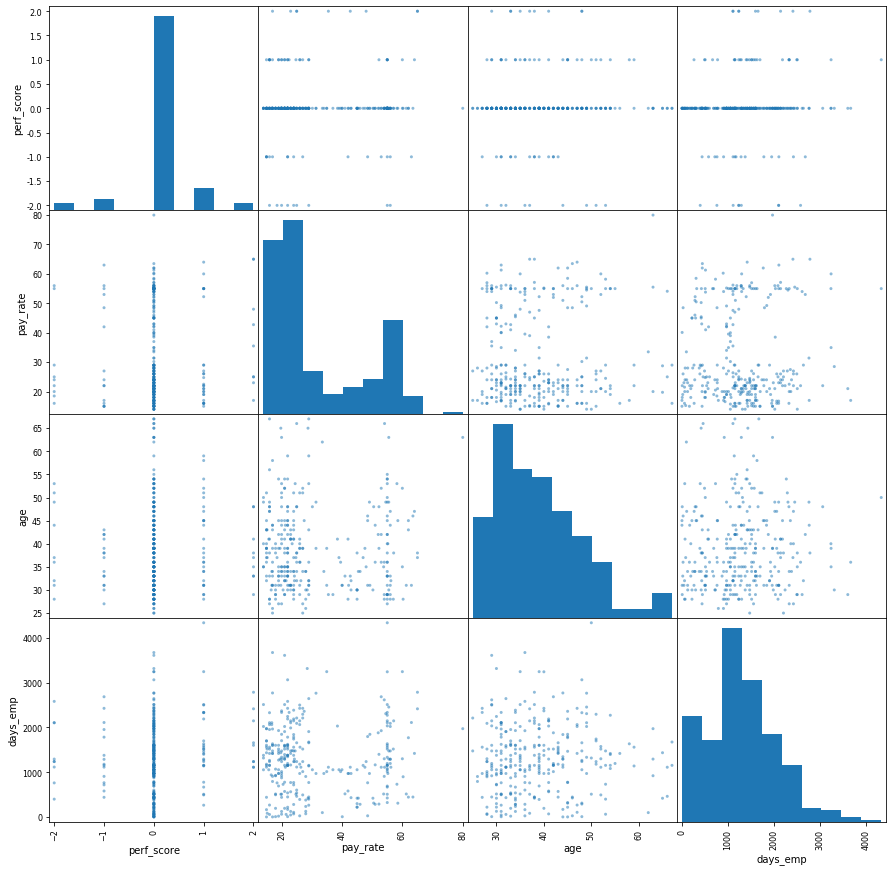

```python
hr_numerical_features = read_sql(f"SELECT perf_score, pay_rate, age, days_emp FROM ({SQL_HR_DATASET_SUBQUERY}) hr")
pd.plotting.scatter_matrix(hr_numerical_features, figsize=(15, 15))
pass
```

#### 2.3.2. Коэффициент корреляции Пирсона

Можно использовать для числовых (numeric) и бинарных ([0, 1]) показателей.

*Действующие сотрудники*

```python
corr_columns = ['is_male', 'is_married', 'is_latino', 'is_termd', 'is_termd_cause',
                'perf_score', 'pay_rate', 'age', 'days_emp']
```

```python
df_corr_non_termd = get_corr_matrix(corr_columns, where='is_termd = 0',
                                    corr_rnd=True, seed=0, subquery=SQL_HR_DATASET_SUBQUERY)
df_corr_non_termd.style.background_gradient(cmap='coolwarm', axis=None).format('{:.2f}')

# Замечание: если градиентная раскраска матрицы не отображается после перезагрузки страницы,
#   нужно заново выполнить текущую ячейку (Ctrl+Enter).
```

|  | is_male | is_married | is_latino | perf_score | pay_rate | age | days_emp | __RND__ |
| --- | --- | --- | --- | --- | --- | --- | --- | --- |
| is_male | 1.00 | -0.03 | 0.02 | -0.03 | 0.13 | 0.01 | -0.07 | 0.05 |
| is_married | -0.03 | 1.00 | -0.04 | -0.11 | 0.04 | -0.04 | -0.03 | 0.02 |
| is_latino | 0.02 | -0.04 | 1.00 | -0.08 | 0.03 | -0.07 | 0.04 | 0.01 |
| perf_score | -0.03 | -0.11 | -0.08 | 1.00 | -0.01 | 0.02 | 0.06 | -0.05 |
| pay_rate | 0.13 | 0.04 | 0.03 | -0.01 | 1.00 | 0.02 | -0.07 | 0.04 |
| age | 0.01 | -0.04 | -0.07 | 0.02 | 0.02 | 1.00 | 0.05 | -0.04 |
| days_emp | -0.07 | -0.03 | 0.04 | 0.06 | -0.07 | 0.05 | 1.00 | -0.07 |
| __RND__ | 0.05 | 0.02 | 0.01 | -0.05 | 0.04 | -0.04 | -0.07 | 1.00 |

Пояснения:

1. Строка/столбец `__RND__` содержит коэффициент корреляции соответствующего показателя со случайным числом.
2. Корреляция показателя со случайным числом стремится к нулю с ростом числа наблюдений (cases).
3. Коэффициенты, не превышающие корреляцию с `__RND__`, следует рассматривать как недостоверные (случайная корреляция).

Наблюдения:

1. `pay_rate` $\uparrow\uparrow$ `is_male` (0.13): ставка выше у сотрудников мужского пола.
2. `is_married` $\uparrow\mathrel{\mspace{-1mu}}\downarrow$ `perf_score` (-0.11): у сотрудников состоящих в браке оценка труда в среднем ниже.
3. `perf_score` $\parallel$ `Pay Rate` (-0.01): размер ставки не связан с оценкой производительности.
4. `age`, `days_emp`: возраст и срок работы не имеют значительной корреляции с другими показателями.

*Уволенные и уволившиеся сотрудники*

```python
df_corr_termd = get_corr_matrix(corr_columns, where='is_termd = 1',
                                    corr_rnd=True, seed=0, subquery=SQL_HR_DATASET_SUBQUERY)
df_corr_termd.style.background_gradient(cmap='coolwarm', axis=None).format('{:.2f}')
```

|  | is_male | is_married | is_latino | is_termd_cause | perf_score | pay_rate | age | days_emp | __RND__ |
| --- | --- | --- | --- | --- | --- | --- | --- | --- | --- |
| is_male | 1.00 | -0.01 | 0.02 | 0.01 | -0.06 | 0.16 | -0.04 | 0.03 | -0.01 |
| is_married | -0.01 | 1.00 | -0.14 | -0.07 | 0.02 | 0.04 | -0.00 | 0.00 | -0.06 |
| is_latino | 0.02 | -0.14 | 1.00 | -0.02 | 0.11 | 0.01 | -0.00 | -0.04 | 0.02 |
| is_termd_cause | 0.01 | -0.07 | -0.02 | 1.00 | -0.20 | 0.19 | -0.11 | -0.03 | 0.03 |
| perf_score | -0.06 | 0.02 | 0.11 | -0.20 | 1.00 | 0.06 | 0.10 | -0.05 | 0.01 |
| pay_rate | 0.16 | 0.04 | 0.01 | 0.19 | 0.06 | 1.00 | 0.09 | -0.03 | 0.19 |
| age | -0.04 | -0.00 | -0.00 | -0.11 | 0.10 | 0.09 | 1.00 | 0.13 | 0.10 |
| days_emp | 0.03 | 0.00 | -0.04 | -0.03 | -0.05 | -0.03 | 0.13 | 1.00 | 0.03 |
| __RND__ | -0.01 | -0.06 | 0.02 | 0.03 | 0.01 | 0.19 | 0.10 | 0.03 | 1.00 |

Наблюдения:

1. `perf_score` $\uparrow\mathrel{\mspace{-1mu}}\downarrow$ `is_termd_cause` (-0.20): увольнения по собственному желанию чаще происходили среди сотрудников с более высокой оценкой труда.
2. `pay_rate` $\uparrow\uparrow$ `is_termd_cause` (0.19): у сотрудников уволенных за нарушение ставка в среднем выше, чем у сотрудников уволившихся по собственному желанию.
   1. Корреляция `pay_rate` с `is_termd_cause` такая же (0.19) как со случайной величиной (`__RND__`). Это значит, что не следует воспринимать это наблюдение как *закономерность*.
3. `age` $\uparrow\mathrel{\mspace{-1mu}}\downarrow$ `is_termd_cause` (-0.11): увольнения за нарушения чаще происходили среди более молодых сотрудников.

*Сотрудники уволившиеся по собственному желанию*

```python
df_corr_termd_no_cause = get_corr_matrix(corr_columns, where='is_termd = 1 AND is_termd_cause = 0',
                                    corr_rnd=True, seed=0, subquery=SQL_HR_DATASET_SUBQUERY)
df_corr_termd_no_cause.style.background_gradient(cmap='coolwarm', axis=None).format('{:.2f}')
```

|  | is_male | is_married | is_latino | perf_score | pay_rate | age | days_emp | __RND__ |
| --- | --- | --- | --- | --- | --- | --- | --- | --- |
| is_male | 1.00 | -0.00 | 0.05 | -0.08 | 0.21 | -0.07 | 0.04 | 0.19 |
| is_married | -0.00 | 1.00 | -0.13 | -0.03 | 0.05 | 0.02 | -0.09 | 0.18 |
| is_latino | 0.05 | -0.13 | 1.00 | 0.10 | -0.01 | 0.02 | -0.02 | 0.09 |
| perf_score | -0.08 | -0.03 | 0.10 | 1.00 | 0.03 | 0.08 | -0.06 | -0.04 |
| pay_rate | 0.21 | 0.05 | -0.01 | 0.03 | 1.00 | 0.04 | -0.00 | 0.10 |
| age | -0.07 | 0.02 | 0.02 | 0.08 | 0.04 | 1.00 | 0.14 | 0.01 |
| days_emp | 0.04 | -0.09 | -0.02 | -0.06 | -0.00 | 0.14 | 1.00 | -0.17 |
| __RND__ | 0.19 | 0.18 | 0.09 | -0.04 | 0.10 | 0.01 | -0.17 | 1.00 |

Наблюдения:

1. `is_male` $\uparrow\uparrow$ `pay_rate` (0.21): увольнения по собственному желанию сотрудников с высокой ставкой, чаще происходили среди сотрудников мужского пола.

*Сотрудники уволенные за нарушение*

```python
df_corr_termd_cause = get_corr_matrix(corr_columns, where='is_termd = 1 AND is_termd_cause = 1',
                                    corr_rnd=True, seed=0, subquery=SQL_HR_DATASET_SUBQUERY)
df_corr_termd_cause.style.background_gradient(cmap='coolwarm', axis=None).format('{:.2f}')
```

|  | is_male | is_married | is_latino | perf_score | pay_rate | age | days_emp | __RND__ |
| --- | --- | --- | --- | --- | --- | --- | --- | --- |
| is_male | 1.00 | -0.04 | -0.24 | 0.03 | -0.04 | 0.26 | -0.06 | -0.04 |
| is_married | -0.04 | 1.00 | -0.21 | 0.16 | 0.08 | -0.31 | 0.60 | 0.34 |
| is_latino | -0.24 | -0.21 | 1.00 | 0.14 | 0.17 | -0.21 | -0.12 | 0.35 |
| perf_score | 0.03 | 0.16 | 0.14 | 1.00 | 0.32 | 0.12 | -0.07 | 0.36 |
| pay_rate | -0.04 | 0.08 | 0.17 | 0.32 | 1.00 | 0.60 | -0.12 | 0.41 |
| age | 0.26 | -0.31 | -0.21 | 0.12 | 0.60 | 1.00 | 0.02 | -0.01 |
| days_emp | -0.06 | 0.60 | -0.12 | -0.07 | -0.12 | 0.02 | 1.00 | 0.17 |
| __RND__ | -0.04 | 0.34 | 0.35 | 0.36 | 0.41 | -0.01 | 0.17 | 1.00 |

Наблюдения:

1. `pay_rate` $\uparrow\uparrow$ `perf_score` (0.32): у сотрудников с более высокой ставкой уволенных за нарушение, оценка производительности выше.
2. `age` $\uparrow\uparrow$ `is_male` (0.26): сотрудники мужского пола уволенные за нарушение, в стреднем старше.
3. `age` $\uparrow\mathrel{\mspace{-1mu}}\downarrow$ `is_married` (-0.31): сотрудники состоящие в браке уволенные за нарушение, в стреднем моложе.
4. `age` $\uparrow\uparrow$ `pay_rate` (0.60): сотрудники с более высокой ставкой уволенные за нарушение, в стреднем старше.
5. `days_emp` $\uparrow\uparrow$ `is_married` (0.60): сотрудники с большим сроком работы уволенные за нарушение, чаще состоят в браке.
6. Высокие коэффициенты корреляции в строке `__RND__` являются индикатором дефицита данных (14 строк в выборке).

### 2.4. Анализ категориальных показателей

#### 2.4.1. Расовый состав

```python
sql_query_dump = []
position_race_count = get_pivot_table_df('position', 'race_desc',
    'count(*) / (sum(count(*)) OVER ()) * 100', total_row_expr='sum(value)', total_col_expr='sum(value)',
    subquery=SQL_HR_DATASET_SUBQUERY, order_columns='total DESC', order_rows='total', out_sql_string=sql_query_dump)
```

```python
print(sql_query_dump[0])
# Демонстрация динамически сформированного SQL запроса
```

```
        WITH row_names AS (
            (
                SELECT "position"::text AS row_name
                FROM (
        WITH hr_dataset__subq_1 AS (
            SELECT
                --categorical
                "maritaldesc"                                       AS marital_desc
              , "Employment Status"                                 AS emp_status
              , "department"                                        AS department
              , "state"                                             AS state
              , "zip"::text                                         AS zip
              , "citizendesc"                                       AS citizen_desc
              , "racedesc"                                          AS race_desc
              , "Reason For Term"                                   AS term_reason
              , "position"                                          AS position
              , "Manager Name"                                      AS manager_name
              , "Employee Source"                                   AS emp_source
              , "Performance Score"                                 AS perf_desc
              , "sex"                                               AS gender_desc
                --binary
              , ("sex" IN ('Male'))::int                            AS is_male
              , "marriedid"                                         AS is_married
              , "Hispanic/Latino"::boolean::int                     AS is_latino
              , ("Date of Termination" IS NOT NULL)::int            AS is_termd
              , ("Employment Status" = 'Terminated for Cause')::int AS is_termd_cause
                --ordinal
              , (CASE
                   WHEN "Performance Score" = 'Exceptional'       THEN 2
                   WHEN "Performance Score" = 'Exceeds'           THEN 1
                   WHEN "Performance Score" = 'Needs Improvement' THEN -1
                   WHEN "Performance Score" = 'PIP'               THEN -2
                   ELSE 0
                 END)                                               AS perf_score
                --numeric
              , "Pay Rate"                                          AS pay_rate
              , "age"                                               AS age
              , "Days Employed"                                     AS days_emp
                --datetime
              , "Date of Hire"                                      AS hire_date
```

[output cut: 131 more lines]

```
            USING (row_name)

            LEFT JOIN (
                SELECT row_name, value AS "Hispanic"
                FROM values_with_total
                WHERE column_name = 'Hispanic'
            ) AS "column Hispanic"
            USING (row_name)

            LEFT JOIN (
                SELECT row_name, value AS "American Indian or Alaska Native"
                FROM values_with_total
                WHERE column_name = 'American Indian or Alaska Native'
            ) AS "column American Indian or Alaska Native"
            USING (row_name)
```

```python
position_race_count
# Демонстрация датафрейма полученного с помощью SQL запроса
```

| race_desc position | total | White | Black or African American | Asian | Two or more races | Hispanic | American Indian or Alaska Native |
| --- | --- | --- | --- | --- | --- | --- | --- |
| IT Manager - Infra | 0.322581 | 0.000000 | 0.000000 | 0.000000 | 0.000000 | 0.322581 | 0.000000 |
| Director of Sales | 0.322581 | 0.322581 | 0.000000 | 0.000000 | 0.000000 | 0.000000 | 0.000000 |
| CIO | 0.322581 | 0.322581 | 0.000000 | 0.000000 | 0.000000 | 0.000000 | 0.000000 |
| Director of Operations | 0.322581 | 0.000000 | 0.322581 | 0.000000 | 0.000000 | 0.000000 | 0.000000 |
| IT Manager - Support | 0.322581 | 0.322581 | 0.000000 | 0.000000 | 0.000000 | 0.000000 | 0.000000 |
| Data Architect | 0.322581 | 0.000000 | 0.322581 | 0.000000 | 0.000000 | 0.000000 | 0.000000 |
| President & CEO | 0.322581 | 0.322581 | 0.000000 | 0.000000 | 0.000000 | 0.000000 | 0.000000 |
| BI Director | 0.322581 | 0.322581 | 0.000000 | 0.000000 | 0.000000 | 0.000000 | 0.000000 |
| IT Director | 0.322581 | 0.000000 | 0.322581 | 0.000000 | 0.000000 | 0.000000 | 0.000000 |
| Software Engineering Manager | 0.322581 | 0.322581 | 0.000000 | 0.000000 | 0.000000 | 0.000000 | 0.000000 |
| IT Manager - DB | 0.645161 | 0.322581 | 0.000000 | 0.000000 | 0.322581 | 0.000000 | 0.000000 |
| Sr. Accountant | 0.645161 | 0.322581 | 0.000000 | 0.322581 | 0.000000 | 0.000000 | 0.000000 |
| Shared Services Manager | 0.645161 | 0.322581 | 0.322581 | 0.000000 | 0.000000 | 0.000000 | 0.000000 |
| Administrative Assistant | 0.967742 | 0.645161 | 0.000000 | 0.322581 | 0.000000 | 0.000000 | 0.000000 |
| Senior BI Developer | 0.967742 | 0.000000 | 0.000000 | 0.967742 | 0.000000 | 0.000000 | 0.000000 |
| Sales Manager | 0.967742 | 0.645161 | 0.322581 | 0.000000 | 0.000000 | 0.000000 | 0.000000 |
| Accountant I | 0.967742 | 0.322581 | 0.645161 | 0.000000 | 0.000000 | 0.000000 | 0.000000 |
| IT Support | 1.290323 | 0.645161 | 0.322581 | 0.000000 | 0.322581 | 0.000000 | 0.000000 |
| Sr. DBA | 1.290323 | 0.645161 | 0.645161 | 0.000000 | 0.000000 | 0.000000 | 0.000000 |
| BI Developer | 1.290323 | 0.645161 | 0.645161 | 0.000000 | 0.000000 | 0.000000 | 0.000000 |
| Sr. Network Engineer | 1.612903 | 0.967742 | 0.000000 | 0.645161 | 0.000000 | 0.000000 | 0.000000 |
| Software Engineer | 2.903226 | 1.290323 | 0.967742 | 0.645161 | 0.000000 | 0.000000 | 0.000000 |
| Network Engineer | 2.903226 | 2.903226 | 0.000000 | 0.000000 | 0.000000 | 0.000000 | 0.000000 |
| Database Administrator | 4.193548 | 2.580645 | 0.967742 | 0.645161 | 0.000000 | 0.000000 | 0.000000 |
| Production Manager | 4.516129 | 2.903226 | 0.645161 | 0.645161 | 0.000000 | 0.322581 | 0.000000 |
| Area Sales Manager | 8.709677 | 3.548387 | 2.580645 | 0.322581 | 1.935484 | 0.000000 | 0.322581 |
| Production Technician II | 18.387097 | 12.580645 | 2.903226 | 1.290323 | 0.645161 | 0.322581 | 0.645161 |
| Production Technician I | 43.870968 | 29.032258 | 6.451613 | 5.161290 | 2.580645 | 0.322581 | 0.322581 |
| total | NaN | 62.258065 | 18.387097 | 10.967742 | 5.806452 | 1.290323 | 1.290323 |

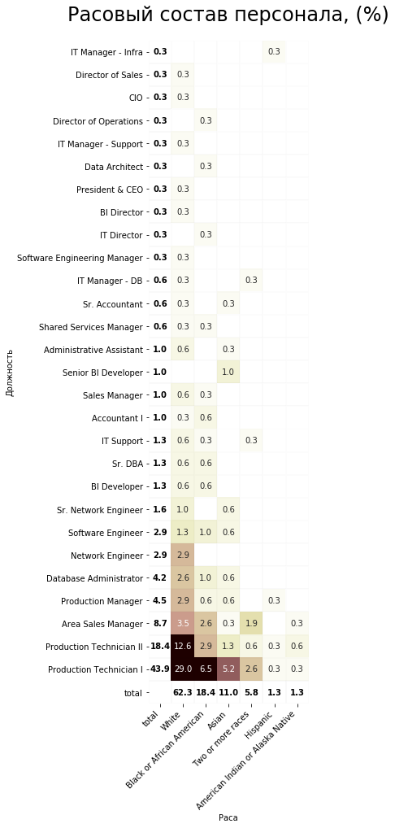

```python
plot_pivot_table(position_race_count,
                 title='Расовый состав персонала, (%)',
                 cmap='pink_r', fmt='.1f')
plt.xlabel('Раса')
plt.ylabel('Должность')
pass
```

```python
column_order = ['White', 'Black or African American', 'Asian', 'Hispanic',
       'American Indian or Alaska Native', 'Two or more races']
position__race__pay_rate = get_pivot_table_df('position', 'race_desc',
    'avg(pay_rate)', total_row_expr='avg(value)', total_col_expr='avg(value)',
    subquery=SQL_HR_DATASET_SUBQUERY,
    order_columns=f"array_position(ARRAY{column_order}, race_desc::text)", order_rows='total')
```

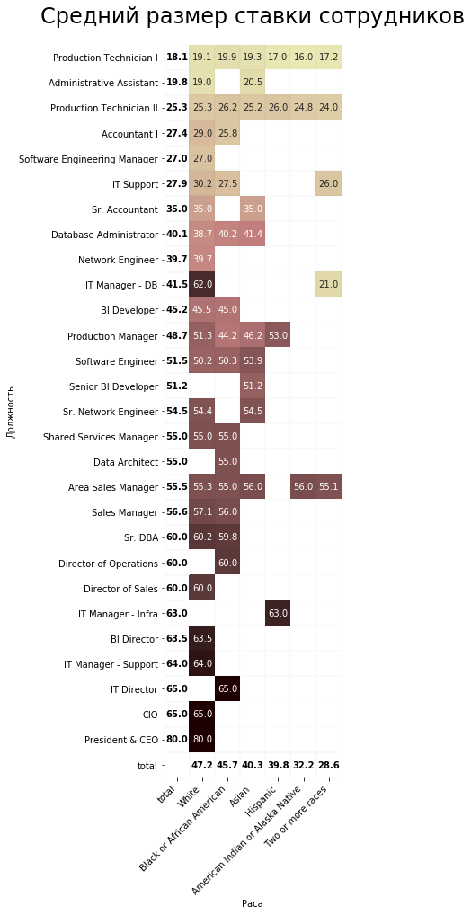

```python
plot_pivot_table(position__race__pay_rate,
                 title='Средний размер ставки сотрудников',
                 cmap='pink_r', fmt='.1f')
plt.xlabel('Раса')
plt.ylabel('Должность')
pass
```

Наблюдения:

1. **3/5** сотрудников компании представлено европейцами (*White*).
   1. Занимаемый спектр должностей: от технических специалистов до директоров.
   2. Более половины участвуют в производстве (`Production Technician I/II`).
   3. Самые низкооплачиваемые должности*: `Software Engineer / Database Administrator / Sr. Network Engineer`.  
      * *представленные сотрудниками более чем одной расы*
   4. Самые высокооплачиваемые должности: `Accountant I / IT Support / Sales Manager / Sr. DBA`.
2. **1/5** сотрудников компании представлено афроамериканцами (*Black or African American*).
   1. Занимаемый спектр должностей: от технических специалистов до директоров, реже, чем европейцы, встречаются среди менеджеров высшего звена.
   2. Более половины участвуют в производстве (`Production Technician I/II`).
   3. Самые низкооплачиваемые должности: `Accountant I / Production Manager / BI Developer`.
   4. Самые высокооплачиваемые должности: `Production Technician I/II`.
3. **1/10** сотрудников компании представлено азиатами (*Asian*).
   1. Занимаемый спектр должностей: от технических специалистов до менеджеров низшего звена.
   2. Более половины участвуют в производстве (`Production Technician I/II`).
   3. Самые низкооплачиваемые должности: -.
   4. Самые высокооплачиваемые должности: `Database Administrator / Software Engineer / Sr. Network Engineer`.
4. Соотношение размера ставки представителей различных рас варьируется в зависимости от занимаемой должности и не подчиняется какой-либо общей закономерности.

#### 2.4.2. Каналы поиска сотрудников

```python
position__emp_source__count = get_pivot_table_df('position', 'Employee Source',
    'count(*) / (sum(count(*)) OVER ()) * 100', total_row_expr='sum(value)', total_col_expr='sum(value)',
    table_name='hr_dataset', order_columns='total DESC', order_rows='total')
```

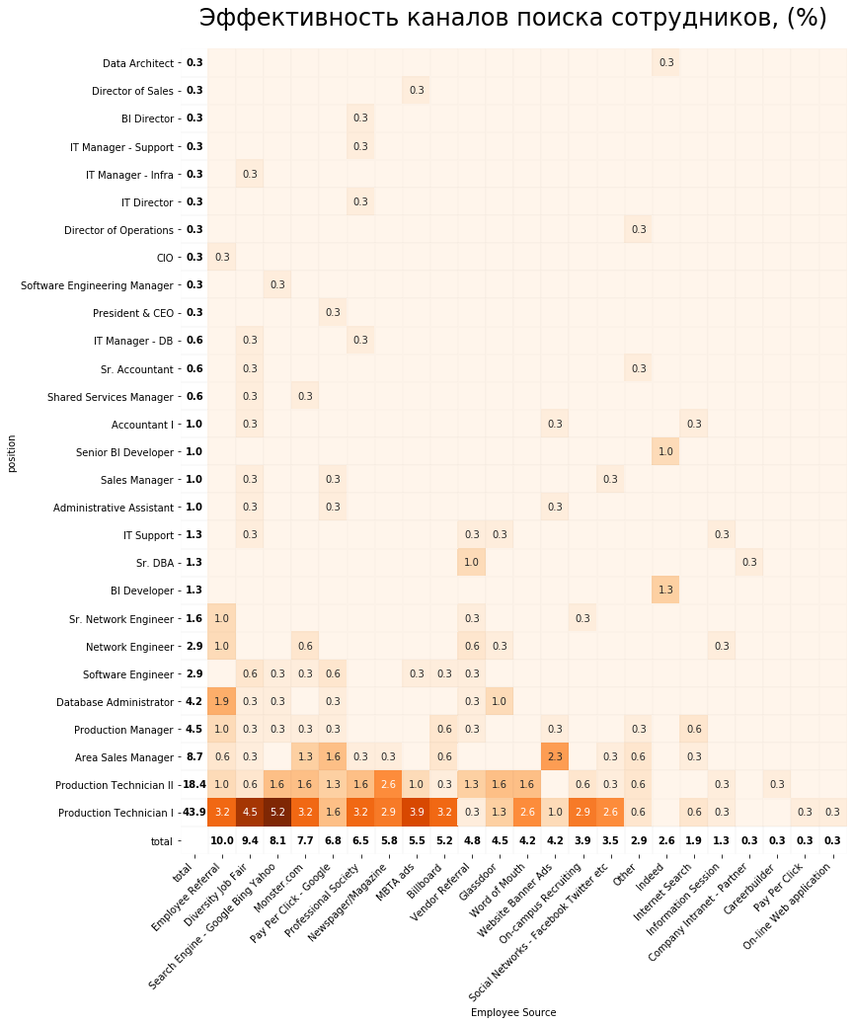

```python
plot_pivot_table(position__emp_source__count,
                 title='Эффективность каналов поиска сотрудников, (%)',
                 cmap='Oranges', fmt='.1f')
```

#### 2.4.3. Качество каналов поиска сотрудников

```python
perf_score__emp_source__count = get_pivot_table_df('perf_score', 'emp_source',
    'count(*)',
    total_row_expr="sum(value * (row_name::int > 0)::int - value * (row_name::int < 0)::int)",
    total_col_expr="count(value)",
    total_row_name='SOURCE SCORE', total_col_name='COUNT',
    subquery=SQL_HR_DATASET_SUBQUERY + 'order by perf_score',
    order_columns='total DESC', order_rows="perf_score DESC")
```

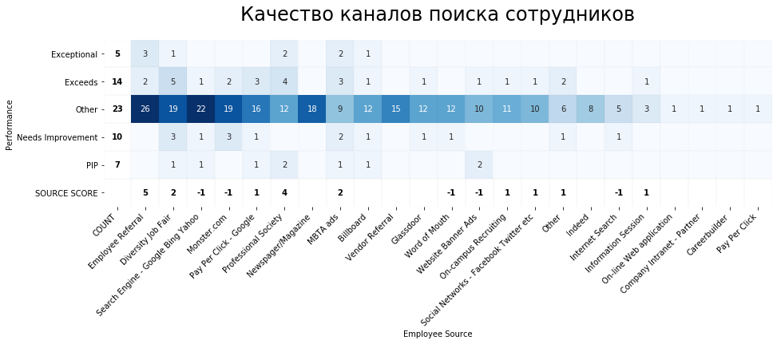

```python
perf_score_map = {'2': 'Exceptional', '1': 'Exceeds', '0': 'Other', '-1': 'Needs Improvement', '-2': 'PIP'}
plot_pivot_table(perf_score__emp_source__count.rename(index=perf_score_map),
                 title='Качество каналов поиска сотрудников',
                 cmap='Blues', fmt='.0f')
plt.yticks(rotation=0)
plt.xlabel('Employee Source')
plt.ylabel('Performance')
pass
```

Описание метрики:

1. `SOURCE SCORE` – оценка качества канала поиска сотрудников. Вычисляется как разница между числом оценок выше нуля (*Exceptional* или *Exceeds*) и числом оценок ниже нуля (*Needs Improvement* или *PIP*)

Наблюдения:

1. Лучшие каналы поиска, согласно оценке `SOURCE SCORE`:
   1. *Employee Referral* (5)
   2. *Professional Society* (4)
   3. *Diversity Job Fair* (2)
   4. *MBTA ads* (2)
2. Худшие каналы поиска, согласно оценке `SOURCE SCORE`:
   1. *Search Engine - Google Bing Yahoo* (-1)
   2. *Monster.com* (-1)
   3. *Word of Mouth* (-1)
   4. *Website Banner Ads* (-1)
   5. *Internet Search* (-1)
3. Среди сотрудников нанятых по рекомендации (*Employee Referral*) нет ни одного с неудовлетворительной оценкой.
4. *Diversity Job Fair, Professional Society, MBTA ads* – встречаются как сотрудники с высокой оценкой, так и с низкой.
5. *Newspager/Magazine, Vendor Referral, Indeed* – 100% сотрудников имеют среднюю оценку.

## 3. Таблица `production_staff`

Сотрудники отдела production

### 3.1. Ознакомление с исходными данными

*Предпросмотр исходных данных*

```python
prod_staff_preview = read_sql("SELECT * FROM production_staff LIMIT 5;")
prod_staff_preview.T
```

|  | 0 | 1 | 2 | 3 | 4 |
| --- | --- | --- | --- | --- | --- |
| id | 1 | 2 | 3 | 4 | 5 |
| Employee Name | Albert, Michael | Bozzi, Charles | Butler, Webster L | Dunn, Amy | Gray, Elijiah |
| Race Desc | White | Asian | White | White | White |
| Date of Hire | 2011-08-01 | 2013-09-30 | 2016-01-28 | 2014-09-18 | 2015-06-02 |
| TermDate | None | 2014-08-07 | None | None | None |
| Reason for Term | N/A - still employed | retiring | N/A - still employed | N/A - still employed | N/A - still employed |
| Employment Status | Active | Voluntarily Terminated | Active | Active | Active |
| Department | Production | Production | Production | Production | Production |
| Position | Production Manager | Production Manager | Production Manager | Production Manager | Production Manager |
| Pay | $54.50 | $50.50 | $55.00 | $51.00 | $54.00 |
| Manager Name | Elisa Bramante | Elisa Bramante | Elisa Bramante | Elisa Bramante | Elisa Bramante |
| Performance Score | Fully Meets | Fully Meets | Exceeds | Fully Meets | Fully Meets |
| Abutments/Hour Wk 1 | 0 | 0 | 0 | 0 | 0 |
| Abutments/Hour Wk 2 | 0 | 0 | 0 | 0 | 0 |
| Daily Error Rate | 0 | 0 | 0 | 0 | 0 |
| 90-day Complaints | 0 | 0 | 0 | 0 | 0 |

*Описание данных*

```python
get_column_stats('production_staff')
```

|  | table_name | column_name | data_type | unique | common_val | common_freq | non_null | count | size_bytes | entropy |
| --- | --- | --- | --- | --- | --- | --- | --- | --- | --- | --- |
| 0 | production_staff | id | integer | 256 | 184 | 0.003906 | 256 | 256 | 1024 | 8.000000 |
| 1 | production_staff | Employee Name | character varying | 209 | None | 0.183594 | 209 | 256 | 3394 | 6.980212 |
| 2 | production_staff | Race Desc | character varying | 6 | White | 0.546875 | 209 | 256 | 2084 | 1.931321 |
| 3 | production_staff | Date of Hire | date | 70 | None | 0.183594 | 209 | 256 | 836 | 5.284105 |
| 4 | production_staff | TermDate | date | 76 | None | 0.675781 | 83 | 256 | 332 | 2.921130 |
| 5 | production_staff | Reason for Term | character varying | 17 | N/A - still employed | 0.460938 | 209 | 256 | 3771 | 2.764453 |
| 6 | production_staff | Employment Status | character varying | 5 | Active | 0.417969 | 209 | 256 | 2933 | 2.001493 |
| 7 | production_staff | Department | character varying | 1 | Production | 0.816406 | 209 | 256 | 3762 | 0.687876 |
| 8 | production_staff | Position | character varying | 3 | Production Technician I | 0.535156 | 209 | 256 | 5004 | 1.646242 |
| 9 | production_staff | Pay | money | 44 | None | 0.183594 | 209 | 256 | 1672 | 4.459380 |
| 10 | production_staff | Manager Name | character varying | 10 | None | 0.183594 | 209 | 256 | 2899 | 3.391169 |
| 11 | production_staff | Performance Score | character varying | 7 | Fully Meets | 0.476562 | 209 | 256 | 2773 | 2.290690 |
| 12 | production_staff | Abutments/Hour Wk 1 | integer | 18 | None | 0.187500 | 208 | 256 | 832 | 3.891610 |
| 13 | production_staff | Abutments/Hour Wk 2 | integer | 20 | None | 0.187500 | 208 | 256 | 832 | 3.861694 |
| 14 | production_staff | Daily Error Rate | integer | 5 | 0 | 0.375000 | 208 | 256 | 832 | 2.192483 |
| 15 | production_staff | 90-day Complaints | integer | 5 | 0 | 0.640625 | 208 | 256 | 832 | 1.533686 |

Описание полей таблицы `production_staff`

| Field | Type | Description |
| --- | --- | --- |
| id | Integer | ID строки |
| Employee Name | Text | Фамилия, имя работника, разделенные запятой. Пример: *Howard, Estelle* |
| Race Desc | Text | Расовая принадлежность: |
|  |  | - *American Indian or Alaska Native* – Индеец или уроженец Аляски |
|  |  | - *Hispanic* – Латиноамериканец |
|  |  | - *Two or more races* – Две и более расы |
|  |  | - *Asian* – Азиат |
|  |  | - *White* – Европеец |
|  |  | - *Black or African American* – Темнокожий или афроамериканец |
| Date of Hire | Date | Дата приема на работу |
| TermDate | Date | Дата увольнения |
| Reason for Term | Text | Причина увольнения: |
|  |  | - *N/A - still employed* – Не уволен |
|  |  | - *N/A - Has not started yet* – Еще не приступил к работе |
|  |  | - *attendance* – Посещаемость |
|  |  | - *more money* – Недостаточная зарплата |
|  |  | - *medical issues* – Проблемы со здоровьем |
|  |  | - *maternity leave - did not return* – Декретный отпуск - не вернулся |
|  |  | - *return to school* – Вернулся в школу |
|  |  | - *relocation out of area* – Переезд |
|  |  | - *performance* – Производительность труда |
|  |  | - *gross misconduct* – Грубое нарушение |
|  |  | - *military* – Воинская обязанность |
|  |  | - *hours* – Неудобные рабочие часы |
|  |  | - *career change* – Смена карьеры |
|  |  | - *unhappy* – Неудовлетворенность |
|  |  | - *retiring* – Уход на пенсию |
|  |  | - *Another position* – Смена позиции в компании |
|  |  | - *no-call, no-show* – Не отвечал на звонки, не явился на работу |
| Employment Status | Text | Статус трудовых отношений: |
|  |  | - *Future Start* – Испытательный срок |
|  |  | - *Voluntarily Terminated* – Уволен по собственному желанию |
|  |  | - *Active* – Действующий сотрудник |
|  |  | - *Terminated for Cause* – Уволен по какой-либо причине |
|  |  | - *Leave of Absence* – Отпуск |
| Department | Text | Название отдела: *None \| Production* |
| Position | Text | Название должности: *Production Technician I \| None \| Production Manager \| Production Technician II* |
| Pay | Numeric | Размер тарифной ставки |
| Manager Name | Text | Имя менеджера. Пример: *Michael Albert* |
| Performance Score | Text | Оценка труда: |
|  |  | - *N/A- too early to review* – Недостаточный срок для оценки |
|  |  | - *Exceptional* – Исключительная |
|  |  | - *Exceeds* – Превосходная |
|  |  | - *Fully Meets* – Удовлетворительная |
|  |  | - *90-day meets* – Прошел испытательный срок |
|  |  | - *Needs Improvement* – Неудовлетворительная |
|  |  | - *PIP* – Performance Improvement Plan / План индивидуального развития |
| Abutments/Hour Wk 1 | Integer | Опор* в час, на 1-й неделе. |
| Abutments/Hour Wk 2 | Integer | Опор* в час, на 2-й неделе. |
| Daily Error Rate | Integer | Ошибок в день |
| 90-day Complaints | Integer | Жалоб за последние 90 дней |

* *Abutment (опора) – название детали для мостовидного зубного протеза*

### 3.2. Подготовка датафрейма

```python
# Подготовка датафрейма production_staff
SQL_PROD_STAFF_SUBQUERY = """
    SELECT
        --categorical
        "Employment Status"                                  AS emp_status
      , "Department"                                         AS department
      , "Race Desc"                                          AS race_desc
      , "Reason for Term"                                    AS term_reason
      , "Position"                                           AS position
      , "Manager Name"                                       AS manager_name
      , "Performance Score"                                  AS perf_desc
        --binary
      , ("TermDate" IS NOT NULL)::int                        AS is_termd
      , ("Employment Status" = 'Terminated for Cause')::int  AS is_termd_cause
        --ordinal
      , (CASE
           WHEN "Performance Score" = 'Exceptional'       THEN 2
           WHEN "Performance Score" = 'Exceeds'           THEN 1
           WHEN "Performance Score" = 'Needs Improvement' THEN -1
           WHEN "Performance Score" = 'PIP'               THEN -2
           ELSE 0
         END)                                                AS perf_score
        --quantitative
      , "Pay"::decimal                                       AS pay_rate
      , ("Abutments/Hour Wk 1" + "Abutments/Hour Wk 2") / 2  AS prod_rate
      , "Daily Error Rate"                                   AS err_rate
      , "90-day Complaints"                                  AS cmpln_rate
        --datetime
      , "Date of Hire"                                       AS hire_date
        --key
      , id
    FROM production_staff
    WHERE "Employee Name" IS NOT NULL
"""
```

Описание добавленных полей:

1. **prod_rate**  
   *Production Rate, темп производства*  
   Числовой показатель, среднее арифметическое показателей `Abutments/Hour Wk 1` и `Abutments/Hour Wk 2`.
2. **perf_score**  
   *Performance Score, оценка производительности*  
   Ординальный показатель, выраженный целым числом из диапазона [-2, 2]:
   1. `'Exceptional' = 2`
   2. `'Exceeds' = 1`
   3. `'Needs Improvement' = -1`
   4. `'PIP' = -2`
   5. `Other = 0`

### 3.3. Анализ корреляционных матриц

```python
prod_numerical_features = read_sql(f"""
    SELECT perf_score, pay_rate, prod_rate, err_rate, cmpln_rate
    FROM ({SQL_PROD_STAFF_SUBQUERY}) prod
    WHERE position IN ('Production Technician I', 'Production Technician II')
""")
```

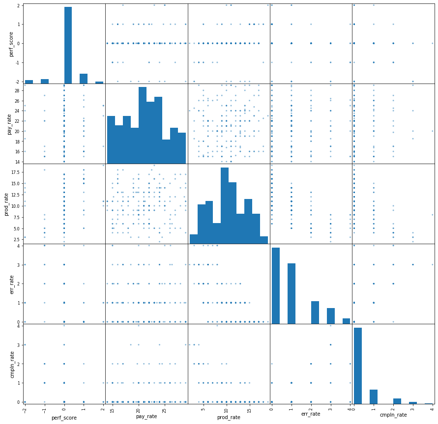

```python
pd.plotting.scatter_matrix(prod_numerical_features, figsize=(15, 15))
pass
```

Наблюдения:

1. `err_rate` $\uparrow\mathrel{\mspace{-1mu}}\downarrow$ `prod_rate`: обратно пропорциональная зависимость между числом ошибок и темпом производства.
2. `cmpln_rate` $\uparrow\mathrel{\mspace{-1mu}}\downarrow$ `prod_rate`: обратно пропорциональная зависимость между числом жалоб и темпом производства.
3. `perf_score` $\uparrow\uparrow$ `prod_rate`: прямо пропорциональная зависимость между оценкой производительности труда и темпом производства.

*Действующие сотрудники*

```python
corr_columns = ['is_termd', 'is_termd_cause', 'perf_score', 'pay_rate',
                'prod_rate', 'err_rate', 'cmpln_rate']
```

```python
prod_corr_non_termd = get_corr_matrix(corr_columns, subquery=SQL_PROD_STAFF_SUBQUERY,
    where="is_termd = 0 AND position IN ('Production Technician I', 'Production Technician II')",
    corr_rnd=True, seed=0)
prod_corr_non_termd.style.background_gradient(cmap='coolwarm', axis=None).format('{:.2f}')
```

|  | perf_score | pay_rate | prod_rate | err_rate | cmpln_rate | __RND__ |
| --- | --- | --- | --- | --- | --- | --- |
| perf_score | 1.00 | 0.01 | 0.33 | -0.22 | -0.20 | 0.25 |
| pay_rate | 0.01 | 1.00 | -0.08 | 0.05 | 0.12 | -0.02 |
| prod_rate | 0.33 | -0.08 | 1.00 | -0.60 | -0.43 | 0.09 |
| err_rate | -0.22 | 0.05 | -0.60 | 1.00 | 0.46 | -0.16 |
| cmpln_rate | -0.20 | 0.12 | -0.43 | 0.46 | 1.00 | -0.17 |
| __RND__ | 0.25 | -0.02 | 0.09 | -0.16 | -0.17 | 1.00 |

Наблюдения:

1. `pay_rate`: ставка не имеет значительной корреляции с другими показателями.
2. `perf_score` $\uparrow\uparrow$ `prod_rate` (0.33): у сотрудников с более высокой оценкой производительности, темп производства выше.
3. `prod_rate` $\uparrow\mathrel{\mspace{-1mu}}\downarrow$ `err_rate` (-0.60): сотрудники с высоким темпом производства, имеют меньше ошибок.
4. `prod_rate` $\uparrow\mathrel{\mspace{-1mu}}\downarrow$ `cmpln_rate` (-0.43): сотрудники с высоким темпом производства, имеют меньше жалоб.
5. `err_rate` $\uparrow\uparrow$ `cmpln_rate` (0.46): сотрудники с бОльшим количеством ошибок, имеют больше жалоб.

*Уволенные и уволившиеся сотрудники*

```python
prod_corr_non_termd = get_corr_matrix(corr_columns, subquery=SQL_PROD_STAFF_SUBQUERY,
    where="is_termd = 1 AND position IN ('Production Technician I', 'Production Technician II')",
    corr_rnd=True, seed=0)
prod_corr_non_termd.style.background_gradient(cmap='coolwarm', axis=None).format('{:.2f}')
```

|  | is_termd_cause | perf_score | pay_rate | prod_rate | err_rate | cmpln_rate | __RND__ |
| --- | --- | --- | --- | --- | --- | --- | --- |
| is_termd_cause | 1.00 | -0.25 | -0.30 | -0.26 | 0.15 | 0.20 | 0.01 |
| perf_score | -0.25 | 1.00 | 0.06 | 0.17 | -0.28 | -0.26 | 0.10 |
| pay_rate | -0.30 | 0.06 | 1.00 | 0.25 | -0.16 | -0.06 | -0.03 |
| prod_rate | -0.26 | 0.17 | 0.25 | 1.00 | -0.70 | -0.52 | 0.01 |
| err_rate | 0.15 | -0.28 | -0.16 | -0.70 | 1.00 | 0.57 | 0.04 |
| cmpln_rate | 0.20 | -0.26 | -0.06 | -0.52 | 0.57 | 1.00 | 0.10 |
| __RND__ | 0.01 | 0.10 | -0.03 | 0.01 | 0.04 | 0.10 | 1.00 |

Наблюдения:

1. Сотрудники уволенные по собственному желанию характеризуются:
   1. Более высокой оценкой труда (`perf_score`)
   2. Более высокой ставкой (`pay_rate`)
   3. Более высоким темпом производства (`prod_rate`)
2. Сотрудники уволенные за нарушение (`Terminated for Cause`) характеризуются:
   1. Более высоким числом ошибок (`err_rate`)
   2. Более высоким числом жалоб (`cmpln_rate`)

*Сотрудники уволенные за нарушение*

```python
prod_corr_non_termd = get_corr_matrix(corr_columns, subquery=SQL_PROD_STAFF_SUBQUERY,
    where="is_termd = 1 AND is_termd_cause = 1 AND position IN ('Production Technician I', 'Production Technician II')",
    corr_rnd=True, seed=0)
prod_corr_non_termd.style.background_gradient(cmap='coolwarm', axis=None).format('{:.2f}')
```

|  | perf_score | pay_rate | prod_rate | err_rate | cmpln_rate | __RND__ |
| --- | --- | --- | --- | --- | --- | --- |
| perf_score | 1.00 | 0.38 | -0.06 | -0.51 | -0.78 | -0.29 |
| pay_rate | 0.38 | 1.00 | -0.28 | 0.11 | 0.08 | -0.24 |
| prod_rate | -0.06 | -0.28 | 1.00 | -0.68 | -0.44 | -0.65 |
| err_rate | -0.51 | 0.11 | -0.68 | 1.00 | 0.77 | 0.43 |
| cmpln_rate | -0.78 | 0.08 | -0.44 | 0.77 | 1.00 | 0.34 |
| __RND__ | -0.29 | -0.24 | -0.65 | 0.43 | 0.34 | 1.00 |

Наблюдения:

1. Высокие коэффициенты корреляции в строке `__RND__` являются индикатором дефицита данных (7 строк в выборке).

### 3.4. Анализ категориальных показателей

*Средние показатели сотрудников под руководством менеджера*

```python
managers_stats = read_sql(f"""
    WITH stats_by_manager AS (
        SELECT
            manager_name
          , count(*) AS group_count
          , avg(pay_rate) AS avg_pay_rate
          , avg(prod_rate) AS avg_prod_rate
          , avg(err_rate) AS avg_err_rate
          , avg(cmpln_rate) AS avg_cmpln_rate
          , avg(perf_score) AS avg_perf_score
        FROM ({SQL_PROD_STAFF_SUBQUERY}) AS prod_staff
        WHERE position IN ('Production Technician I', 'Production Technician II') AND is_termd = 0
        GROUP BY manager_name
    )
    , stats_normalized AS (
        SELECT
            manager_name || ' (' || group_count || ')' AS manager_name
          ,  (avg_prod_rate     - min(avg_prod_rate ) OVER ()) * 0.9 / (max(avg_prod_rate ) OVER () - min(avg_prod_rate ) OVER ()) + 0.1 AS "Prod Rate"
          ,  (avg_perf_score    - min(avg_perf_score) OVER ()) * 0.9 / (max(avg_perf_score) OVER () - min(avg_perf_score) OVER ()) + 0.1 AS "Performance"
          ,  (avg_pay_rate      - min(avg_pay_rate  ) OVER ()) * 0.9 / (max(avg_pay_rate  ) OVER () - min(avg_pay_rate  ) OVER ()) + 0.1 AS "Pay Rate"
          , -(avg_err_rate      - min(avg_err_rate  ) OVER ()) * 0.9 / (max(avg_err_rate  ) OVER () - min(avg_err_rate  ) OVER ()) - 0.1 AS "Error Rate"
          , -(avg_cmpln_rate    - min(avg_cmpln_rate) OVER ()) * 0.9 / (max(avg_cmpln_rate) OVER () - min(avg_cmpln_rate) OVER ()) - 0.1 AS "Compaints Rate"
          , -(group_count::real - min(group_count   ) OVER ()) * 0.9 / (max(group_count   ) OVER () - min(group_count   ) OVER ()) - 0.1 AS "Count"
        FROM stats_by_manager
    )
    SELECT *
    FROM stats_normalized
    ORDER BY "Prod Rate" DESC, "Error Rate" DESC, "Compaints Rate" DESC
""")
```

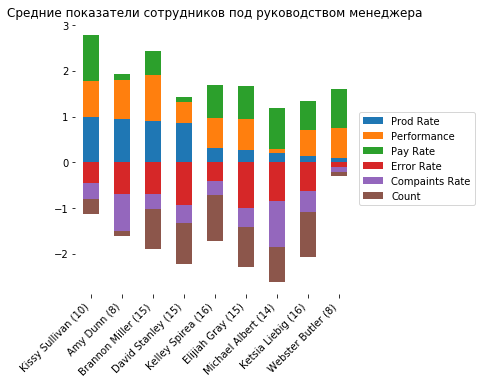

```python
managers_stats.set_index('manager_name').plot.bar(figsize=(5,5), stacked=True)
plt.xticks(rotation=45, ha='right')
plt.xlabel('')
plt.title('Средние показатели сотрудников под руководством менеджера')
plt.legend(loc='center left', bbox_to_anchor=(1, 0.5))
plt.box(False)
pass
```

Комментарий к диаграмме:

1. В скобках, после имени менеджера, указано число подчиненных.
2. *Stacked bar chart* – столбчатая диаграмма с накоплением.
3. Показатели относительные и варьируются от 0.1* до 1.0, где 0.1 - минимальный показатель *по всем группам*, 1.0 - максимальный.\ * *Минимальный уровень выбран равным 0.1 для улучшения визуального восприятия диаграммы - все столбцы имеют равное число сегментов, даже если один из показателей равен 0*
4. Показатели делятся на *позитивные* (больше-лучше) и *негативные* (меньше-лучше):
   1. *Позитивные* на диаграмме "растут" вверх (в направлении $+Y$)
      1. Темп производства (основной показатель)
      2. Оценка производительности
      3. Ставка
   2. *Негативные* – "растут" вниз (в направлении $-Y$)
      1. Число ошибок
      2. Число жалоб
      3. Число сотрудников

Наблюдения:

1. Ведущие менеджеры:
   1. *Kissy Sullivan*
   2. *Amy Dunn*
   3. *Brannon Miller*
2. Отстающие:
   1. *Webster Butler*
   2. *Ketsia Liebig*
   3. *Michael Albert*

*Структура персонала*

```python
current_grouping = read_sql(f"""
    WITH tech_staff AS (
        SELECT raw."Employee Name" AS emp_name, prod_staff.*
        FROM ({SQL_PROD_STAFF_SUBQUERY}) AS prod_staff
        JOIN production_staff AS raw USING (id)
        WHERE "Position" IN ('Production Technician I', 'Production Technician II')
          AND prod_rate IS NOT NULL
          AND is_termd = 0
    )
    , managers AS (
        SELECT manager_name
        FROM tech_staff
        GROUP BY manager_name
        ORDER BY avg(prod_rate) DESC
    )
    SELECT *
    FROM managers
    CROSS JOIN lateral (
        SELECT emp_name, prod_rate, err_rate, cmpln_rate
        FROM tech_staff AS subgroup
        WHERE subgroup.manager_name = managers.manager_name
        ORDER BY prod_rate
    ) AS low__prod_rate__group
""")
```

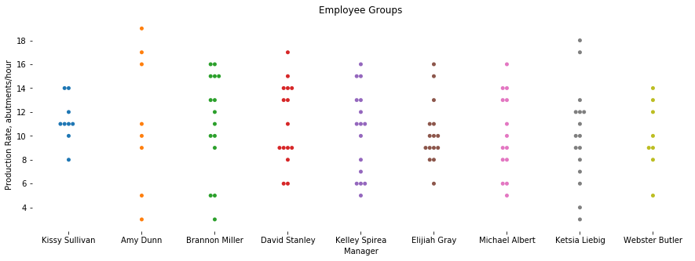

```python
plt.figure(figsize=(15, 5))
ax = sns.swarmplot('manager_name', 'prod_rate', data=current_grouping)
ax.set(xlabel='Manager', ylabel='Production Rate, abutments/hour', title='Employee Groups')
plt.box(False)
pass
```

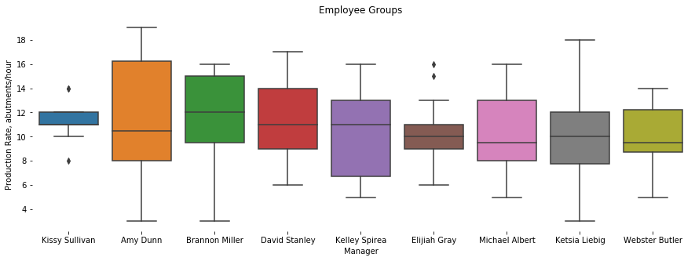

```python
plt.figure(figsize=(15,5))
ax = sns.boxplot('manager_name', 'prod_rate', data=current_grouping)
ax.set(xlabel='Manager', ylabel='Production Rate, abutments/hour', title='Employee Groups')
plt.box(False)
```

Наблюдения:

1. Распределение сотрудников по темпу производства (*Production Rate*) можно охарактеризовать как равномерное: нет ярко-выраженных ведущих/отстающих групп.
2. В 1-й и 6-й группах есть сотрудники с темпом производства значительно выше среднего.
3. В 1-й группе есть один отстающий сотрудник.

Подобные нетипичные случаи, стоящие "особняком" называются *outliers (выбросы)*. Следующий запрос вычисляет допустимые границы и ищет выбросы по каждой группе.

```python
emp_outliers = read_sql(f"""
    WITH tech_staff AS (
        SELECT raw."Employee Name" AS emp_name, prod_staff.*
        FROM ({SQL_PROD_STAFF_SUBQUERY}) AS prod_staff
        JOIN production_staff AS raw USING (id)
        WHERE "Position" IN ('Production Technician I', 'Production Technician II')
          AND prod_rate IS NOT NULL
          AND is_termd = 0
    )
    , managers AS (
        SELECT manager_name,
              2.5 * percentile_cont(0.25) WITHIN GROUP (ORDER BY prod_rate)
            - 1.5 * percentile_cont(0.75) WITHIN GROUP (ORDER BY prod_rate) AS lower_bound,
              2.5 * percentile_cont(0.75) WITHIN GROUP (ORDER BY prod_rate)
            - 1.5 * percentile_cont(0.25) WITHIN GROUP (ORDER BY prod_rate) AS upper_bound
        FROM tech_staff
        GROUP BY manager_name
    )
    SELECT manager_name, emp_name, prod_rate, 'Below' AS level
    FROM managers
    JOIN tech_staff USING (manager_name)
    WHERE prod_rate < lower_bound

    UNION ALL

    SELECT manager_name, emp_name, prod_rate, 'Above' AS level
    FROM managers
    JOIN tech_staff USING (manager_name)
    WHERE prod_rate > upper_bound

    ORDER BY manager_name
""")
emp_outliers
```

|  | manager_name | emp_name | prod_rate | level |
| --- | --- | --- | --- | --- |
| 0 | Elijiah Gray | Faller, Megan | 16 | Above |
| 1 | Elijiah Gray | Smith, Joe | 15 | Above |
| 2 | Kissy Sullivan | Garneau, Hamish | 8 | Below |
| 3 | Kissy Sullivan | Bugali, Josephine | 14 | Above |
| 4 | Kissy Sullivan | Davis, Daniel | 14 | Above |

## 4. Таблица `recruiting_costs`

Затраты на подбор персонала

### 4.1. Ознакомление с исходными данными

*Предпросмотр исходных данных*

```python
recr_costs_preview = read_sql("SELECT * FROM recruiting_costs LIMIT 50;", index_col='id')
recr_costs_preview
```

| id | Employment Source | January | February | March | April | May | June | July | August | September | October | November | December | Total |
| --- | --- | --- | --- | --- | --- | --- | --- | --- | --- | --- | --- | --- | --- | --- |
| 1 | Billboard | 520 | 520 | 520 | 520 | 0 | 0 | 612 | 612 | 729 | 749 | 910 | 500 | 6192 |
| 2 | Careerbuilder | 410 | 410 | 410 | 820 | 820 | 410 | 410 | 820 | 820 | 1230 | 820 | 410 | 7790 |
| 3 | Company Intranet - Partner | 0 | 0 | 0 | 0 | 0 | 0 | 0 | 0 | 0 | 0 | 0 | 0 | 0 |
| 4 | Diversity Job Fair | 0 | 5129 | 0 | 0 | 0 | 0 | 0 | 4892 | 0 | 0 | 0 | 0 | 10021 |
| 5 | Employee Referral | 0 | 0 | 0 | 0 | 0 | 0 | 0 | 0 | 0 | 0 | 0 | 0 | 0 |
| 6 | Glassdoor | 0 | 0 | 0 | 0 | 0 | 0 | 0 | 0 | 0 | 0 | 0 | 0 | 0 |
| 7 | Information Session | 0 | 0 | 0 | 0 | 0 | 0 | 0 | 0 | 0 | 0 | 0 | 0 | 0 |
| 8 | Internet Search | 0 | 0 | 0 | 0 | 0 | 0 | 0 | 0 | 0 | 0 | 0 | 0 | 0 |
| 9 | MBTA ads | 640 | 640 | 640 | 640 | 640 | 640 | 640 | 1300 | 1300 | 1300 | 1300 | 1300 | 10980 |
| 10 | Monster.com | 500 | 500 | 500 | 440 | 500 | 500 | 440 | 500 | 440 | 440 | 500 | 500 | 5760 |
| 11 | Newspager/Magazine | 629 | 510 | 293 | 810 | 642 | 675 | 707 | 740 | 772 | 805 | 838 | 870 | 8291 |
| 12 | On-campus Recruiting | 0 | 0 | 2500 | 0 | 0 | 2500 | 0 | 0 | 2500 | 0 | 0 | 0 | 7500 |
| 13 | On-line Web application | 0 | 0 | 0 | 0 | 0 | 0 | 0 | 0 | 0 | 0 | 0 | 0 | 0 |
| 14 | Other | 0 | 492 | 0 | 829 | 744 | 0 | 610 | 0 | 0 | 510 | 0 | 810 | 3995 |
| 15 | Pay Per Click | 110 | 110 | 60 | 121 | 110 | 109 | 130 | 146 | 105 | 109 | 105 | 110 | 1323 |
| 16 | Pay Per Click - Google | 330 | 330 | 180 | 362 | 197 | 152 | 389 | 437 | 315 | 327 | 315 | 176 | 3509 |
| 17 | Professional Society | 100 | 100 | 100 | 100 | 100 | 100 | 100 | 100 | 100 | 100 | 100 | 100 | 1200 |
| 18 | Search Engine - Google Bing Yahoo | 330 | 410 | 388 | 372 | 472 | 412 | 416 | 495 | 619 | 502 | 389 | 378 | 5183 |
| 19 | Social Networks - Facebook Twitter etc | 420 | 481 | 452 | 479 | 392 | 508 | 578 | 466 | 389 | 439 | 491 | 478 | 5573 |
| 20 | Vendor Referral | 0 | 0 | 0 | 0 | 0 | 0 | 0 | 0 | 0 | 0 | 0 | 0 | 0 |
| 21 | Website Banner Ads | 400 | 400 | 300 | 388 | 592 | 610 | 620 | 669 | 718 | 767 | 816 | 865 | 7143 |
| 22 | Word of Mouth | 0 | 0 | 0 | 0 | 0 | 0 | 0 | 0 | 0 | 0 | 0 | 0 | 0 |

*Описание данных*

```python
get_column_stats('recruiting_costs')
```

|  | table_name | column_name | data_type | unique | common_val | common_freq | non_null | count | size_bytes | entropy |
| --- | --- | --- | --- | --- | --- | --- | --- | --- | --- | --- |
| 0 | recruiting_costs | id | integer | 22 | 22 | 0.045455 | 22 | 22 | 88 | 4.459432 |
| 1 | recruiting_costs | Employment Source | character varying | 22 | Billboard | 0.045455 | 22 | 22 | 405 | 4.459432 |
| 2 | recruiting_costs | January | integer | 11 | 0 | 0.500000 | 22 | 22 | 88 | 2.638807 |
| 3 | recruiting_costs | February | integer | 13 | 0 | 0.409091 | 22 | 22 | 88 | 3.071735 |
| 4 | recruiting_costs | March | integer | 13 | 0 | 0.454545 | 22 | 22 | 88 | 2.949464 |
| 5 | recruiting_costs | April | integer | 13 | 0 | 0.454545 | 22 | 22 | 88 | 2.949464 |
| 6 | recruiting_costs | May | integer | 12 | 0 | 0.500000 | 22 | 22 | 88 | 2.729716 |
| 7 | recruiting_costs | June | integer | 12 | 0 | 0.500000 | 22 | 22 | 88 | 2.729716 |
| 8 | recruiting_costs | July | integer | 13 | 0 | 0.454545 | 22 | 22 | 88 | 2.949464 |
| 9 | recruiting_costs | August | integer | 13 | 0 | 0.454545 | 22 | 22 | 88 | 2.949464 |
| 10 | recruiting_costs | September | integer | 13 | 0 | 0.454545 | 22 | 22 | 88 | 2.949464 |
| 11 | recruiting_costs | October | integer | 13 | 0 | 0.454545 | 22 | 22 | 88 | 2.949464 |
| 12 | recruiting_costs | November | integer | 12 | 0 | 0.500000 | 22 | 22 | 88 | 2.729716 |
| 13 | recruiting_costs | December | integer | 12 | 0 | 0.454545 | 22 | 22 | 88 | 2.858555 |
| 14 | recruiting_costs | Total | integer | 15 | 0 | 0.363636 | 22 | 22 | 88 | 3.368523 |

Описание полей таблицы `recruiting_costs`

| Field | Type | Description |
| --- | --- | --- |
| id | Integer | ID строки |
| Employee Source | Text | Канал поиска соискателей: |
|  |  | - *Billboard* – Рекламный щит |
|  |  | - *Employee Referral* – Рекомендация сотрудника |
|  |  | - *Vendor Referral* – Рекомендация продавца |
|  |  | - *Word of Mouth* – Из уст в уста / Сарафанное радио |
|  |  | - *Pay Per Click* – Оплата за клик |
|  |  | - *Pay Per Click - Google* – Оплата за клик - Google |
|  |  | - *Social Networks - Facebook Twitter etc* – Социальные сети - Facebook, Twitter и т.д. |
|  |  | - *Search Engine - Google Bing Yahoo* – Поисковая система - Google Bing Yahoo |
|  |  | - *Professional Society* – Профессиональное сообщество |
|  |  | - *Diversity Job Fair* – Ярмарка вакансий |
|  |  | - *Company Intranet - Partner* – Внутренняя сеть компании и партнеров |
|  |  | - *On-line Web application* – Онлайн веб-приложение |
|  |  | - *Newspager/Magazine* – Газеты / Журналы |
|  |  | - *Website Banner Ads* – Баннерная реклама на сайте |
|  |  | - *Information Session* – Презентация организации |
|  |  | - *On-campus Recruiting* – Набор в университете / колледже |
|  |  | - *Internet Search* – Поиск в интернете |
|  |  | - *Careerbuilder* – www.careerbuilder.com - Сайт для соискателей |
|  |  | - *Glassdoor* – www.glassdoor.com - Сайт для соискателей |
|  |  | - *Monster.com* – www.monster.com - Сайт для соискателей |
|  |  | - *MBTA ads* – www.mbta.com – Реклама на транспорте и остановках (Massachusetts Bay Transportation Authority) |
|  |  | - *Other* – Другой |
| January .. December | Integer | Затраты на рекрутинг, за указанный месяц |
| Total | Integer | Затраты на рекрутинг, всего |

### 4.2. Подготовка датафрейма

При запросе к таблице `recruiting_costs` можно столкнуться со следующей ошибкой:

```
SELECT "January"
FROM recruiting_costs

/* output */
...
column "January" does not exist
LINE 2:     SELECT "January"
                   ^
HINT:  Perhaps you meant to reference the column "recruiting_costs.January ".
```

Ошибка связана с тем, что идентификатор колонки `"January "` содержит пробел на конце. Для дальнейшей работы с данными следует привести идентификаторы колонок к единому формату.

```python
SQL_RECR_COSTS_SUBQUERY = """
    SELECT *
    FROM (SELECT * FROM recruiting_costs)
      AS recr_costs(id, emp_source, jan, feb, mar, apr, may, jun, jul, aug, sep, oct, nov, dec, total)
"""
```

### 4.3. Расходы на каналы поиска сотрудников

```python
recr_costs = read_sql(f"""
    WITH recr_costs(emp_source, total, jan, feb, mar, apr, may, jun, jul, aug, sep, oct, nov, dec) AS (
        SELECT emp_source, total::real / 1000,
            jan::real / 1000, feb::real / 1000, mar::real / 1000, apr::real / 1000, may::real / 1000, jun::real / 1000,
            jul::real / 1000, aug::real / 1000, sep::real / 1000, oct::real / 1000, nov::real / 1000, dec::real / 1000
        FROM ({SQL_RECR_COSTS_SUBQUERY}) AS subquery
    )
    (
        SELECT emp_source, total::real / (SELECT sum(total) FROM recr_costs) * 100 AS "Total, %",
            jan, feb, mar, apr, may, jun, jul, aug, sep, oct, nov, dec
        FROM recr_costs
        ORDER BY "Total, %"

    ) UNION ALL (

        SELECT 'Total (k)', sum(total),
            sum(jan), sum(feb), sum(mar), sum(apr), sum(may), sum(jun),
            sum(jul), sum(aug), sum(sep), sum(oct), sum(nov), sum(dec)
        FROM recr_costs
    )

""", index_col='emp_source')
```

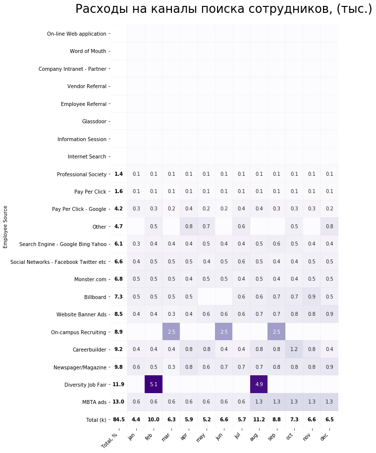

```python
plot_pivot_table(recr_costs, cmap='Purples', title='Расходы на каналы поиска сотрудников, (тыс.)', fmt='.1f')
plt.ylabel('Employee Source')
pass
```

Наблюдения:

1. Наиболее эффективные (как было показано ранее) каналы поиска сотрудников (`Employee Referral, Vendor Referral, Word of Mouth`) не требуют расходов.
2. `Careerbuilder` стоит на 4-м месте по уровню расходов (9.2%), являясь при этом одним из наименее эффективных каналов поиска.
3. Расходы на `MBTA ads` возросли более чем в 2 раза начиная с августа.

## 5. Таблица `salary_grid`

Зарплатная сетка

### 5.1. Ознакомление с исходными данными

*Предпросмотр исходных данных*

```python
salary_preview = read_sql("SELECT * FROM salary_grid LIMIT 50;", index_col='id')
salary_preview
```

| id | Position | Salary Min | Salary Mid | Salary Max | Hourly Min | Hourly Mid | Hourly Max |
| --- | --- | --- | --- | --- | --- | --- | --- |
| 1 | Administrative Assistant | 30000 | 40000 | 50000 | 14.42 | 19.23 | 24.04 |
| 2 | Sr. Administrative Assistant | 35000 | 45000 | 55000 | 16.83 | 21.63 | 26.44 |
| 3 | Accountant I | 42274 | 51425 | 62299 | 20.32 | 24.72 | 29.95 |
| 4 | Accountant II | 50490 | 62158 | 74658 | 24.27 | 29.88 | 35.89 |
| 5 | Sr. Accountant | 63264 | 76988 | 92454 | 30.42 | 37.01 | 44.45 |
| 6 | Network Engineer | 50845 | 66850 | 88279 | 24.44 | 32.14 | 42.44 |
| 7 | Sr. Network Engineer | 79428 | 99458 | 120451 | 38.19 | 47.82 | 57.91 |
| 8 | Database Administrator | 50569 | 68306 | 93312 | 24.31 | 32.84 | 44.86 |
| 9 | Sr. DBA | 92863 | 116007 | 139170 | 44.65 | 55.77 | 66.91 |
| 10 | Production Technician I | 30000 | 40000 | 50000 | 14.42 | 19.23 | 24.04 |
| 11 | Production Technician II | 38000 | 48000 | 58000 | 18.27 | 23.08 | 27.88 |
| 12 | Lead Production Technician | 45000 | 55000 | 65000 | 21.63 | 26.44 | 31.25 |

*Описание данных*

```python
get_column_stats('salary_grid')
```

|  | table_name | column_name | data_type | unique | common_val | common_freq | non_null | count | size_bytes | entropy |
| --- | --- | --- | --- | --- | --- | --- | --- | --- | --- | --- |
| 0 | salary_grid | id | integer | 12 | 5 | 0.083333 | 12 | 12 | 48 | 3.584963 |
| 1 | salary_grid | Position | character varying | 12 | Sr. DBA | 0.083333 | 12 | 12 | 241 | 3.584963 |
| 2 | salary_grid | Salary Min | integer | 11 | 30000 | 0.166667 | 12 | 12 | 48 | 3.418296 |
| 3 | salary_grid | Salary Mid | integer | 11 | 40000 | 0.166667 | 12 | 12 | 48 | 3.418296 |
| 4 | salary_grid | Salary Max | integer | 11 | 50000 | 0.166667 | 12 | 12 | 48 | 3.418296 |
| 5 | salary_grid | Hourly Min | real | 11 | 14.42 | 0.166667 | 12 | 12 | 48 | 3.418296 |
| 6 | salary_grid | Hourly Mid | real | 11 | 19.23 | 0.166667 | 12 | 12 | 48 | 3.418296 |
| 7 | salary_grid | Hourly Max | real | 11 | 24.04 | 0.166667 | 12 | 12 | 48 | 3.418296 |

Описание полей таблицы `salary_grid`

| Field | Type | Description |
| --- | --- | --- |
| id | Integer | ID строки |
| Position | Text | Позиция в компании. Пример: *Production Technician I* |
| Salary Min | Integer | Годовой оклад, min |
| Salary Mid | Integer | Годовой оклад, median |
| Salary Max | Integer | Годовой оклад, max |
| Hourly Min | Real | Размер почасовой оплаты, min |
| Hourly Mid | Real | Размер почасовой оплаты, median |
| Hourly Max | Real | Размер почасовой оплаты, max |

*Годовой оклад исходя из расчета 40 ч/нед. (2080 ч/год).*

### 5.2. Подготовка датафрейма

```python
SQL_SALARY_SUBQUERY = """
    SELECT
        "Position"   AS position
      , "Salary Min" AS annual_min
      , "Salary Mid" AS annual_mid
      , "Salary Max" AS annual_max
      , "Hourly Min" AS hourly_min
      , "Hourly Mid" AS hourly_mid
      , "Hourly Max" AS hourly_max
    FROM salary_grid
"""
sal = read_sql(SQL_SALARY_SUBQUERY)
sal
```

|  | position | annual_min | annual_mid | annual_max | hourly_min | hourly_mid | hourly_max |
| --- | --- | --- | --- | --- | --- | --- | --- |
| 0 | Administrative Assistant | 30000 | 40000 | 50000 | 14.42 | 19.23 | 24.04 |
| 1 | Sr. Administrative Assistant | 35000 | 45000 | 55000 | 16.83 | 21.63 | 26.44 |
| 2 | Accountant I | 42274 | 51425 | 62299 | 20.32 | 24.72 | 29.95 |
| 3 | Accountant II | 50490 | 62158 | 74658 | 24.27 | 29.88 | 35.89 |
| 4 | Sr. Accountant | 63264 | 76988 | 92454 | 30.42 | 37.01 | 44.45 |
| 5 | Network Engineer | 50845 | 66850 | 88279 | 24.44 | 32.14 | 42.44 |
| 6 | Sr. Network Engineer | 79428 | 99458 | 120451 | 38.19 | 47.82 | 57.91 |
| 7 | Database Administrator | 50569 | 68306 | 93312 | 24.31 | 32.84 | 44.86 |
| 8 | Sr. DBA | 92863 | 116007 | 139170 | 44.65 | 55.77 | 66.91 |
| 9 | Production Technician I | 30000 | 40000 | 50000 | 14.42 | 19.23 | 24.04 |
| 10 | Production Technician II | 38000 | 48000 | 58000 | 18.27 | 23.08 | 27.88 |
| 11 | Lead Production Technician | 45000 | 55000 | 65000 | 21.63 | 26.44 | 31.25 |

### 5.3. Выход зарплаты за границы диапазона

```python
pay_rate_level = read_sql(f"""
    SELECT
        position AS "Position"
      , sum((pay_rate < hourly_min)::int)::real / count(*) * 100 AS "Lower"
      , sum((pay_rate BETWEEN hourly_min AND hourly_max)::int)::real / count(*) * 100 AS "Good"
      , sum((pay_rate > hourly_max)::int)::real / count(*) * 100 AS "Higher"
    FROM ({SQL_HR_DATASET_SUBQUERY}) AS hr_dataset
    INNER JOIN ({SQL_SALARY_SUBQUERY}) AS salary USING (position)
    GROUP BY "Position"
    ORDER BY "Lower" DESC, "Higher"
""", index_col='Position')
```

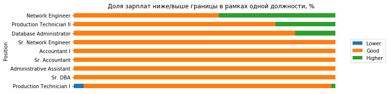

```python
ax = pay_rate_level.plot.barh(stacked=True, figsize=(10, 3))
plt.box(False)
plt.title('Доля зарплат ниже/выше границы в рамках одной должности, %')
ax.tick_params(axis='x', which='both', bottom=False, top=False, labelbottom=False)
ax.legend(bbox_to_anchor=(1,.5), loc='center left')
pass
```

```python
emp_pay_low = read_sql(f"""
    SELECT "Employee Name", position AS "Position", "Pay Rate", hourly_min AS "Pay Rate Min",
        hourly_min::decimal - "Pay Rate" AS "Underpay"
    FROM hr_dataset
    INNER JOIN ({SQL_SALARY_SUBQUERY}) AS salary USING (position)
    WHERE hourly_min > "Pay Rate"
    ORDER BY hourly_min - "Pay Rate" DESC
    LIMIT 50
""")
emp_pay_low

# Список сотрудников с зарплатой, выходящей за нижнюю границу зарплатной сетки
```

|  | Employee Name | Position | Pay Rate | Pay Rate Min | Underpay |
| --- | --- | --- | --- | --- | --- |
| 0 | Gross, Paula | Production Technician I | 14.0 | 14.42 | 0.42 |
| 1 | Knapp, Bradley J | Production Technician I | 14.0 | 14.42 | 0.42 |
| 2 | Meads, Elizabeth | Production Technician I | 14.0 | 14.42 | 0.42 |
| 3 | Stanford,Barbara M | Production Technician I | 14.0 | 14.42 | 0.42 |
| 4 | Sutwell, Barbara | Production Technician I | 14.0 | 14.42 | 0.42 |

```python
emp_pay_high = read_sql(f"""
    SELECT "Employee Name", position AS "Position", "Pay Rate", hourly_max AS "Pay Rate Max",
        "Pay Rate"::decimal - hourly_max AS "Overpay"
    FROM hr_dataset
    INNER JOIN ({SQL_SALARY_SUBQUERY}) AS salary USING (position)
    WHERE hourly_max < "Pay Rate"
    ORDER BY "Pay Rate" - hourly_max DESC
    LIMIT 50
""")
emp_pay_high

# Список сотрудников с зарплатой, выходящей за верхнюю границу зарплатной сетки
```

|  | Employee Name | Position | Pay Rate | Pay Rate Max | Overpay |
| --- | --- | --- | --- | --- | --- |
| 0 | Turpin, Jumil | Network Engineer | 49.10 | 42.44 | 6.660001 |
| 1 | Shepard, Anita | Network Engineer | 47.00 | 42.44 | 4.560001 |
| 2 | Goble, Taisha | Database Administrator | 48.50 | 44.86 | 3.639999 |
| 3 | Bacong, Alejandro | Network Engineer | 45.00 | 42.44 | 2.560001 |
| 4 | Winthrop, Jordan | Production Technician II | 29.00 | 27.88 | 1.120001 |
| 5 | Akinkuolie, Sarah | Production Technician II | 29.00 | 27.88 | 1.120001 |
| 6 | Demita, Carla | Production Technician II | 29.00 | 27.88 | 1.120001 |
| 7 | Fitzpatrick, Michael J | Production Technician II | 29.00 | 27.88 | 1.120001 |
| 8 | Gonzalez, Juan | Production Technician II | 29.00 | 27.88 | 1.120001 |
| 9 | Moumanil, Maliki | Production Technician II | 29.00 | 27.88 | 1.120001 |
| 10 | Peters, Lauren | Production Technician II | 29.00 | 27.88 | 1.120001 |
| 11 | Sahoo, Adil | Production Technician II | 29.00 | 27.88 | 1.120001 |
| 12 | Tejeda, Lenora | Production Technician II | 28.75 | 27.88 | 0.870001 |
| 13 | Clukey, Elijian | Production Technician I | 24.75 | 24.04 | 0.709999 |
| 14 | Merlos, Carlos | Network Engineer | 43.00 | 42.44 | 0.560001 |
| 15 | Smith, Sade | Production Technician I | 24.50 | 24.04 | 0.459999 |
| 16 | Salter, Jason | Database Administrator | 45.00 | 44.86 | 0.139999 |
| 17 | Homberger, Adrienne J | Production Technician II | 28.00 | 27.88 | 0.120001 |
| 18 | Latif, Mohammed | Production Technician II | 28.00 | 27.88 | 0.120001 |
| 19 | Pelletier, Ermine | Production Technician II | 28.00 | 27.88 | 0.120001 |
| 20 | Hutter, Rosalie | Production Technician II | 28.00 | 27.88 | 0.120001 |

## 6. Поверка гипотез

Вот несколько утверждений из интервью 2008 года *\"Thomas Sowell - Gender Bias and Income Disparity: A Myth?\"* ([youtube.com](https://www.youtube.com/watch?v=8EK6Y1X_xa4)), взятого у американского экономиста [Томаса Соуэлла](https://en.wikipedia.org/wiki/Thomas_Sowell):

1. Разница в доходе (income) между мужчинами и женщинами не является следствием гендерной дискриминации у нанимателей, а зависит от профессиональных характеристик сотрудника.
2. Длительный перерыв в трудовой деятельности у женщин состоящих в браке, обычно связанный с рождением ребенка, отрицательным образом сказывается на профессиональных характеристиках.
3. Снижение профессиональных характеристик со временем, в большей степени касается быстроразвивающихся профессий ("high rate of obsolescence"), таких, как компьютерный инженер, и в меньшей степени таких, как библиотекарь и учитель.
4. Неравный доход среди мужчин и женщин объясняется асимметричным распределением домашних обязанностей.

> ... the asymmetrical division of domestic responsibilities produces male-female differences in incomes ...

> — Economic Facts and Fallacies: Second Edition By Thomas Sowell

*Замечание.* Поскольку в датасете нет информации о количестве отработанных каждым сотрудником часов, нельзя непосредственно проверить гипотезу о доходах (income), поэтому будут проверены сопутствующие гипотезы.

**Гипотеза 1.** *Производительность (performance score)* женщин, не состоявших в браке, выше.

Вторая гипотеза была выдвинута, в том числе, на основании предыдущих результатов анализа корреляционных матриц, которые обнаружили связь между показателями `pay_rate` $\uparrow\uparrow$ `is_male` (0.13) среди действующих сотрудников.

**Гипотеза 2.** Зависимость между *полом сотрудника* и *размером ставки* является следствием гендерной дискриминации в данной компании.

### 6.1. Проверка гипотезы 1

*Анализ производительности в зависимости от пола и семейного положения*

```python
def get_single_perf(is_male=0):
    return read_sql(f"""
        WITH hr_subset AS ({SQL_HR_DATASET_SUBQUERY})

        , single_male_perf_count AS (
            SELECT
                count(*) AS cnt
              , CASE WHEN marital_desc = 'Single' THEN 'Never Married' ELSE 'Was Married' END AS was_married
              , perf_level
            FROM hr_subset
            WHERE is_male = %(is_male)s
            GROUP BY was_married, perf_level)

        , perf_pct(pct, was_married, perf_level) AS (
            SELECT cnt / sum(cnt) OVER (PARTITION BY was_married), was_married, perf_level FROM single_male_perf_count)

        SELECT was_married, low, average, high
        FROM (SELECT * FROM perf_pct WHERE perf_level = 'low') AS t1(low, was_married)
        JOIN (SELECT * FROM perf_pct WHERE perf_level = 'average') AS t2(average, was_married) USING (was_married)
        JOIN (SELECT * FROM perf_pct WHERE perf_level = 'high') AS t3(high, was_married) USING (was_married)
    """,
    params={'is_male': is_male}, index_col='was_married')
```

```python
df_single_female_perf = get_single_perf(is_male=0)
df_single_male_perf = get_single_perf(is_male=1)
```

```python
curr_palet = 'Paired'
```

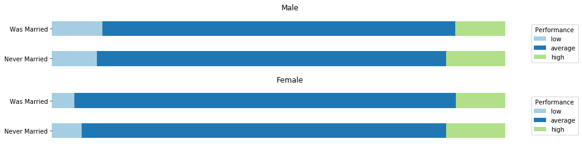

```python
fig, axes = plt.subplots(2, figsize=(14, 4))

with sns.color_palette(curr_palet, 3):
    df_single_male_perf.plot.barh(stacked=True, ax=axes[0], title='Male')
    df_single_female_perf.plot.barh(stacked=True, ax=axes[1], title='Female')

for ax in axes:
    ax.set_ylabel('')
    ax.set_frame_on(False)
    ax.spines['bottom'].set_visible(False)
    ax.tick_params(axis='x', which='both', bottom=False, top=False, labelbottom=False)
    ax.legend(title='Performance', bbox_to_anchor=(1,.5), loc='center left')
```

Наблюдение:

1. Сотрудники (как мужчины, так и женщины), не состоявшие в браке, имеют более высокую оценку производительности труда.
2. Больше сотрудников с низкой производительностью среди мужчин.

**Гипотеза 1 – подтверждена.** *Женщины не состоявшие в браке* имеют более высокую оценку производительности труда.

### 6.2. Проверка гипотезы 2

*Анализ показателя `Pay Rate` (ставка)*

```python
def get_mid_pay_rate(positions=None):
    """ >>> get_mid_pay_rate(('Production Technician I',))
        ...
        >>> get_mid_pay_rate(('Production Technician I', 'Production Technician II'))
        ...
    """
    return read_sql(f"""
            WITH mid_pay_rate AS (
                SELECT
                    'Median Pay Rate' AS row_name
                  , gender_desc AS column_name
                  , percentile_cont(0.5) WITHIN GROUP (ORDER BY pay_rate) AS value
                FROM ({SQL_HR_DATASET_SUBQUERY}) AS subq_1
                {'--' if positions is None else ''} WHERE position IN %s
                GROUP BY gender_desc
            )
            SELECT
                female.value AS "Female"
              , male.value AS "Male"
            FROM (SELECT * FROM mid_pay_rate WHERE column_name = 'Female') female
            JOIN (SELECT * FROM mid_pay_rate WHERE column_name = 'Male') male USING (row_name)
        """, params=[positions])
```

```python
df_mid_pay_rate = get_mid_pay_rate()
```

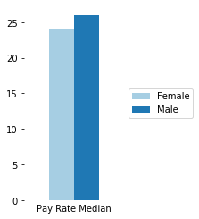

```python
with sns.color_palette(curr_palet):
    ax = df_mid_pay_rate.plot.bar(figsize=(2, 4))
plt.box(False)
ax.set_xlabel('Pay Rate Median')
ax.tick_params(axis='x', which='both', bottom=False, top=False, labelbottom=False)
ax.legend(bbox_to_anchor=(1,.5), loc='center left')
pass
```

Наблюдение:

1. Мужчины имеют более высокую медианную ставку, чем женщины, что на первый взгляд подкрепляет теорию о гендерной дискриминации. Дальнейший анализ покажет, что этот вывод – пример *заблуждений*, которые могут возникнуть при поверхностном анализе с использованием недостаточного количества параметров.

*Ставка и численность сотрудников на различных должностях*

```python
df_position_gender__pay_rate = read_sql(f"""
        SELECT
            position
          , gender_desc
          , percentile_cont(0.5) WITHIN GROUP (ORDER BY pay_rate) AS median
        FROM ({SQL_HR_DATASET_SUBQUERY}) AS subq_1
        GROUP BY position, gender_desc
        ORDER BY count(*) DESC, position
    """)

df_position_gender_dist = read_sql(f"""
        SELECT
            position
          , gender_desc
          , count(*)
        FROM ({SQL_HR_DATASET_SUBQUERY}) AS subq_1
        GROUP BY position, gender_desc
        ORDER BY count(*) DESC, position
    """)
```

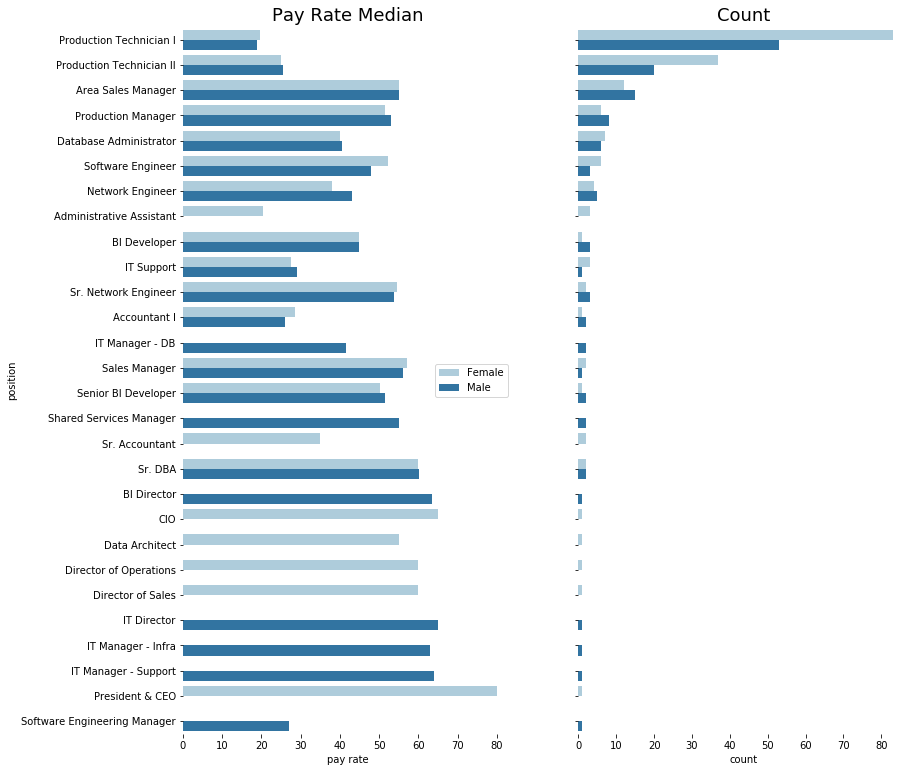

```python
fig, [ax_0, ax_1] = plt.subplots(ncols=2, sharey=True, figsize=(13,13))

sns.barplot('median', 'position', 'gender_desc', data=df_position_gender__pay_rate, ax=ax_0, palette=curr_palet)
ax_0.set_frame_on(False)
ax_0.set_title('Pay Rate Median', fontsize='18')
ax_0.set_xlabel('pay rate')
ax_0.legend(loc='center right')

sns.barplot('count', 'position', 'gender_desc', data=df_position_gender_dist, ax=ax_1, palette=curr_palet)
ax_1.set_frame_on(False)
ax_1.set_title('Count', fontsize='18')
ax_1.set_ylabel('')
ax_1.legend(loc='center right').remove()
pass
```

Наблюдения:

1. В рассматриваемой компании мужчины чаще занимают *высокооплачиваемые*, управляющие должности (manager / director)
2. Женщины чаще занимают *низкооплачиваемые*, технические должности (production technician / administrative assistant)
3. Это объясняет причину *заблуждения*: приведенная ранее статистика не учитывает такой параметр, как занимаемая должность
4. Согласно диаграмме (слева), размер медианной ставки для мужчин и женщин в рамках одной должности в большинстве случаев примерно одинаковый, без значительных отклонений в ту или иную сторону

Чтобы сделать вывод по 2-й гипотезе (о размере ставки) необходимо рассмотреть размер ставки в рамках конкретной должности.

*Ставка сотрудников на технических и управляющих должностях*

```python
# Медианная ставка сотрудников на технических должностях
df_mid_pay_rate_prod = get_mid_pay_rate(('Production Technician I', 'Production Technician II'))
# Медианная ставка сотрудников на управляющих должностях
df_mid_pay_rate_mgr = get_mid_pay_rate(('Area Sales Manager', 'Production Manager'))
```

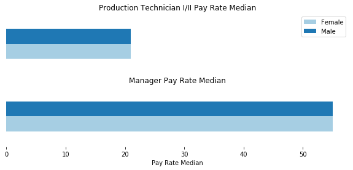

```python
with sns.color_palette(curr_palet):
    fig, [ax_0, ax_1] = plt.subplots(nrows=2, figsize=(10, 4), sharex=True)

    df_mid_pay_rate_prod.plot.barh(title='Production Technician I/II Pay Rate Median', ax=ax_0)
    ax_0.set_frame_on(False)
    ax_0.tick_params(axis='x', which='both', bottom=False, top=False, labelbottom=False)
    ax_0.tick_params(axis='y', which='both', left=False, right=False, labelleft=False)

    df_mid_pay_rate_mgr.plot.barh(title='Manager Pay Rate Median', ax=ax_1)
    ax_1.set_frame_on(False)
    ax_1.legend().remove()
    plt.xlabel('Pay Rate Median')
    ax_1.tick_params(axis='y', which='both', left=False, right=False, labelleft=False)
```

Наблюдения:

1. Медианная ставка не зависит от пола сотрудника в рамках одной должности.

**Гипотеза 2 – опровергнута.** Зависимость между полом сотрудника и размером ставки не является следствием гендерной дискриминации и объясняется лишь неравнозначностью занимаемых должностей.

## 7. Рекомендации для отдела кадров

### 7.1. Рекомендации по стратегии набора персонала

#### Каналы поиска

Согласно результатам анализа, рекомендуемые (с учетом рейтинга) каналы поиска сотрудников:

1. На позицию *Production Technician I*:
   1. *Diversity Job Fair*
   2. *MBTA ads*
   3. *Professional Society*
2. На позицию *Production Technician II*:
   1. *Newspager/Magazine*
   2. *Diversity Job Fair*
   3. *MBTA ads*
3. На позицию *Area Sales Manager / Production Manager*:
   1. *Pay Per Click - Google*
   2. *Employee Referral*
   3. *Billboard*
4. На позицию *Database Administrator / Software Engineer / (Sr.) Network Engineer*:
   1. *Employee Referral*
   2. *Vendor Referral*
   3. *Diversity Job Fair*
   4. *Glassdoor*
5. На позицию *Data Architect / (Senior) BI Developer*:
   1. *Indeed*
6. На позицию *Manager (lower) / Accountant / Support / Assistant*:
   1. *Diversity Job Fair*
7. На позицию *Manager (middle)*:
   1. *Pay Per Click - Google*
8. На позицию *Manager (top) / Director*:
   1. *Professional Society*

#### Лучшие позиции для сотрудников мужского/женского пола

Согласно результатам анализа имеют больший размер ставки:

- женщины на позициях:
  1. *Production Technician I*
  2. *Software Engineer*
  3. *Administrative Assistant*
  4. *Accountant I*
  5. *Sales Manager*
  6. *Sr. Accountant*
  7. *CIO*
- мужчины на позициях:
  1. *Production Technician II*
  2. *Production Manager*
  3. *Database Administrator*
  4. *Network Engineer*
  5. *IT Support*
  6. *IT Manager - DB*
  7. *Senior BI Developer*

#### Лучшие позиции для представителей разных рас

Согласно результатам анализа имеют больший размер ставки:

| Раса | Позиции |
| --- | --- |
| *Азиаты* | *Database Administrator / Software Engineer / Sr. Network Engineer* |
| *Европейцы* | *Accountant I / IT Support / Sales Manager / Sr. DBA* |
| *Латиноамериканцы* | *Production Manager* |
| *Индейцы или уроженцы Аляски* | *Area Sales Manager* |
| *Темнокожие или афроамериканцы* | *Production Technician I/II* |

#### Семейное положение

Согласно результатам анализа сотрудники, никогда *не состоявшие в браке*, имеют более *высокую оценку* производительности труда.

#### Возраст

Согласно результатам анализа увольнения за *нарушения* чаще происходили среди более *молодых* сотрудников.

### 7.2. Рекомендации по взаимодействию с имеющимися сотрудниками

#### Возможные стратегии реорганизации структуры персонала в отделе production

##### Стратегия 1

Равномерное распределение

```python
def new_sql_staff_groups(evenly=True):
    return f"""
        WITH tech_staff AS (
            SELECT raw."Employee Name" AS emp_name, prod_staff.*
            FROM ({SQL_PROD_STAFF_SUBQUERY}) AS prod_staff
            JOIN production_staff AS raw USING (id)
            WHERE "Position" IN ('Production Technician I', 'Production Technician II')
              AND prod_rate IS NOT NULL
              AND is_termd = 0
        )
        , managers AS (
            SELECT manager_name, row_number() OVER (ORDER BY avg(prod_rate) DESC) - 1 AS manager_pos
            FROM tech_staff
            GROUP BY manager_name
            ORDER BY avg(prod_rate) DESC
        )
        , subordinates AS (
            SELECT emp_name, prod_rate, row_number() OVER (ORDER BY prod_rate DESC) - 1 AS emp_pos
            FROM tech_staff
            ORDER BY prod_rate DESC
        )
        SELECT *
        FROM managers
        CROSS JOIN lateral (
            SELECT emp_name, prod_rate
            FROM subordinates AS subgroup
            WHERE subgroup.emp_pos {'%' if evenly else '/'} 9 = managers.manager_pos
            ORDER BY prod_rate
        ) AS employees
    """
```

```python
grouping_1 = read_sql(new_sql_staff_groups(evenly=True))
```

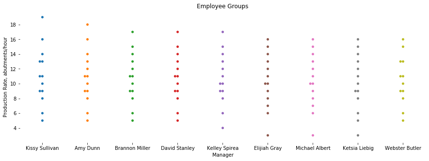

```python
plt.figure(figsize=(15, 5))
ax = sns.swarmplot('manager_name', 'prod_rate', data=grouping_1)
ax.set(xlabel='Manager', ylabel='Production Rate, abutments/hour', title='Employee Groups')
plt.box(False)
pass
```

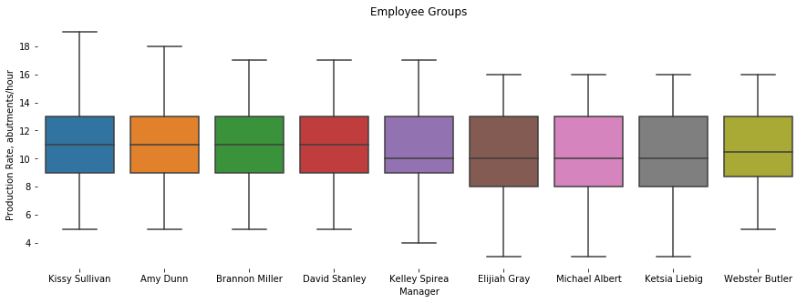

```python
plt.figure(figsize=(15,5))
ax = sns.boxplot('manager_name', 'prod_rate', data=grouping_1)
ax.set(xlabel='Manager', ylabel='Production Rate, abutments/hour', title='Employee Groups')
plt.box(False)
```

1. Идея данной стратегии в создании коллективов сбалансированных по некоторому признаку (в данном случае по темпу производства).
2. Преуспевающие и отстающие сотрудники распределены равномерно.
3. Все коллективы изначально находятся в равных условиях, но с течением времени навыки руководителя определят позицию коллектива в общем зачете.

##### Стратегия 2

Деление на классы

```python
grouping_2 = read_sql(new_sql_staff_groups(evenly=False))
```

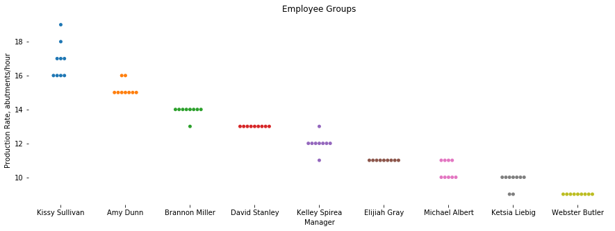

```python
plt.figure(figsize=(15, 5))
ax = sns.swarmplot('manager_name', 'prod_rate', data=grouping_2)
ax.set(xlabel='Manager', ylabel='Production Rate, abutments/hour', title='Employee Groups')
plt.box(False)
pass
```

1. Идея данной стратегии в делении персонала на классы (верхний-средний-нижний).
2. Такое деление открывает возможность более индивидуального подхода к персоналу.

##### Стратегия 3

Комбинированный подход. Два лидера

```python
grouping_3 = read_sql(f"""
    WITH tech_staff AS (
        SELECT
            row_number() OVER (ORDER BY prod_rate DESC) - 1 AS emp_pos
          , raw."Employee Name" AS emp_name
          , prod_staff.*
        FROM ({SQL_PROD_STAFF_SUBQUERY}) AS prod_staff
        JOIN production_staff AS raw USING (id)
        WHERE "Position" IN ('Production Technician I', 'Production Technician II')
          AND prod_rate IS NOT NULL
          AND is_termd = 0
    )
    , managers AS (
        SELECT manager_name, row_number() OVER (ORDER BY avg(prod_rate) DESC) - 1 AS group_id
        FROM tech_staff
        GROUP BY manager_name
        ORDER BY avg(prod_rate) DESC
    )
    , group_1 AS (
        SELECT emp_name, prod_rate, (row_number() OVER (ORDER BY prod_rate DESC) - 1) % 2 AS group_id
        FROM tech_staff
        WHERE emp_pos / 9 < 2
    )
    , group_2 AS (
        SELECT emp_name, prod_rate, (row_number() OVER (ORDER BY prod_rate DESC) - 1) % 7 + 2 AS group_id
        FROM tech_staff
        WHERE emp_pos / 9 >= 2
    )
    SELECT *
    FROM managers
    CROSS JOIN lateral (
        SELECT emp_name, prod_rate
        FROM group_1
        WHERE group_1.group_id = managers.group_id

        UNION ALL

        SELECT emp_name, prod_rate
        FROM group_2
        WHERE group_2.group_id = managers.group_id

        ORDER BY prod_rate DESC
    ) AS employees
""")
```

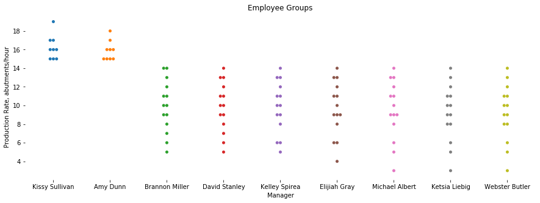

```python
plt.figure(figsize=(15, 5))
ax = sns.swarmplot('manager_name', 'prod_rate', data=grouping_3)
ax.set(xlabel='Manager', ylabel='Production Rate, abutments/hour', title='Employee Groups')
plt.box(False)
pass
```

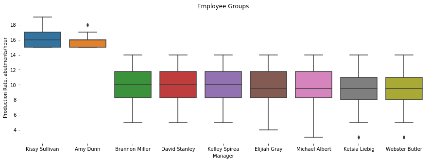

```python
plt.figure(figsize=(15,5))
ax = sns.boxplot('manager_name', 'prod_rate', data=grouping_3)
ax.set(xlabel='Manager', ylabel='Production Rate, abutments/hour', title='Employee Groups')
plt.box(False)
```

1. Среди сотрудников с максимальными показателями выделяются две эквивалентные группы.
2. Группам назначаются два ведущих менеджера.
3. Две группы должны находиться в условиях конкуренции и "задавать планку" остальным коллективам.

```python
with pd.option_context('display.max_rows', 200):
    display(grouping_3[['emp_name', 'manager_name']])

# Схема реорганизации структуры персонала согласно стратегии 3
```

|  | emp_name | manager_name |
| --- | --- | --- |
| 0 | Anderson, Linda | Kissy Sullivan |
| 1 | Girifalco, Evelyn | Kissy Sullivan |
| 2 | Walker, Roger | Kissy Sullivan |
| 3 | Harrison, Kara | Kissy Sullivan |
| 4 | Osturnka, Adeel | Kissy Sullivan |
| 5 | Adinolfi, Wilson K | Kissy Sullivan |
| 6 | Smith, Joe | Kissy Sullivan |
| 7 | Billis, Helen | Kissy Sullivan |
| 8 | Trang, Mei | Kissy Sullivan |
| 9 | Jeannite, Tayana | Amy Dunn |
| 10 | Monkfish, Erasumus | Amy Dunn |
| 11 | Faller, Megan | Amy Dunn |
| 12 | Clukey, Elijian | Amy Dunn |
| 13 | Gonzalez, Cayo | Amy Dunn |
| 14 | Sahoo, Adil | Amy Dunn |
| 15 | Ngodup, Shari | Amy Dunn |
| 16 | Hankard, Earnest | Amy Dunn |
| 17 | Sparks, Taylor | Amy Dunn |
| 18 | Fancett, Nicole | Brannon Miller |
| 19 | Sullivan, Timothy | Brannon Miller |
| 20 | Ivey, Rose | Brannon Miller |
| 21 | Biden, Lowan M | Brannon Miller |
| 22 | Darson, Jene'ya | Brannon Miller |
| 23 | Handschiegl, Joanne | Brannon Miller |
| 24 | Barone, Francesco A | Brannon Miller |
| 25 | Hutter, Rosalie | Brannon Miller |
| 26 | Mahoney, Lauren | Brannon Miller |
| 27 | Crimmings, Jean | Brannon Miller |
| 28 | Heitzman, Anthony | Brannon Miller |
| 29 | Stoica, Rick | Brannon Miller |

[output cut: 86 more lines]